# Projet CNRT Mines et Territoire

THION Romuald, UNC

Décembre 2022

# Evolution du niveau d’équipement des ménages NC

Cette étude porte sur le Niveau d’Equipement des Ménages (**NEM**) sur les Bases Individuelles (**BI**) et les Bases Logements (**BL**) du Recensement de la Population (**RP**) de Nouvelle-Calédonie (NC) sur les années 2009, 2014 et 2019. Cette étude est réalisé par THION Romuald, maître de conférences en informatique à l’UNC, dans les locaux de l’ISEE dans le cadre du projet CNRT *Mine et Territoires* (**M&T**).

## Préparation et chargement des données

Les sources de données suivantes sont utilisées dans cette étude :

- `src-iris/` : le shapefile des IRIS UNC09-14-19 créé par l’ISEE pour le projet M&T.
- `src-communes/` : les limites administratives terrestres (BDADMIN-NC) des communes, [source](https://georep-dtsi-sgt.opendata.arcgis.com/maps/limites-administratives-terrestres-1/about). Le shapefile est chargé en SQL et enrichi avec l’information du type de site retenu dans le projet M&T (*centre*, *usine/métallurgique* ou *témoin*). Un export CSV `communes.csv` permet d’avoir les noms correctement encodés.
- `src-desserte/` : le calcul à partir de la BDROUTE-NC de la durée minimale/moyenne/médiane maximale à chacun des sites miniers, voir rapport technique consacré dans les livrables du projet. Les données sont ré-exportées dans le fichier `duree-iris.csv` dans un format utilisable facilement en R.
- `src-rp/` : les BI et BL des RP 2009, 2014 et 2019 accompagnés de leurs dictionnaires de données fournis par l’ISEE. La conversion du format `dbf` dans le format `csv` est réalisée par le script `export_dbf_to_csv.R` à exécuter une fois pour toutes.

On charge les BL des trois années, en ne gardant que les ménages qui sont des résidences principales (`filter(CATL == 1)`). On crée la clef de jointure `IDLOG` entre la BI et la BL comme la concaténation des variables suivantes, dans l’ordre :

- `NC` : numéro de la commune (de 01 à 33),
- `DIST` : code ilot / district. C’est l’unité géographique de référence de l’ISEE. On utilisera plutôt la commune et un IRIS intermédiaire entre commune et îlot créé pour le projet, appelé `IRIS` ou `IRISUNC`
- `RADR` : rang de la construction, rang de l’adresse.
- `RLOG` : rang de logement.

Si les questionnaires des RP 2009, 2014 et 2019 sont très similaires, certaines modalités changent néanmoins, dont notamment dans la BL 2019:

- la variable `BATI` en 2019, les anciennes modalités 2009 et 2009 sont disponibles dans la variable `TYPC14`.
- la variable `DIPLM` en 2019, les anciennes modalités 2009 et 2009 sont disponibles dans la variable `DIPLM14`.

On note qu’à ce stade, on ne se sert pas encore des BI.

```r
bl09_r <- read_csv2("./src-rp/BL2009.csv") %>%
  filter(CATL == 1) %>%
  mutate(
    # on crée la clef de jointure entre BL et BI
    IDLOG = paste(NC, DIST, RADR, RLOG, sep = "-")
  )

bl14_r <- read_csv2("./src-rp/BL2014.csv") %>%
  filter(CATL == 1) %>%
  mutate(
    # on crée la clef de jointure entre BL et BI
    IDLOG = paste(NC, DIST, RADR, RLOG, sep = "-")
  )

bl19_r <- read_csv2("./src-rp/BL2019.csv") %>%
  filter(CATL == 1) %>%
  mutate(
    # on transforme les modalités BATI et DIPLM de 2019 pour reprendre celles de 2009/2014
    # afin que les années soient comparables
    BATI = TYPC14,
    DIPLM = DIPLM14,
    # on crée la clef de jointure entre BL et BI
    IDLOG = paste(NC, DIST, RADR, RLOG, sep = "-")
  )

# un erreur corrigée manuellement dans le CSV
# ligne 54501, colonne 71 (année), la valeur 198? a été remplacée par 1985.
# 1 54501    71 a double 198?
```

In fine, les BL contiennent :

- 72637 logements d’intérêt en 2009
- 85063 logements d’intérêt en 2014
- 90813 logements d’intérêt en 2019

On charge le dictionnaire des communes et des IRIS pour avoir leurs noms correctement orthographiés.

```r
communes <- read_csv2("src-communes/communes.csv") %>% column_to_rownames("CODE_COM")
iris_csv <- read_csv2("src-iris/iris.csv") %>% select(IRIS, LIB_IRIS)
```

## Calcul de l’indicateur de niveau d’équipement des ménages (NEM)

On reprend la méthodologie générale des études socio-énonomiques précédemment réalisées dans le volet A du projet M1T dans les stages d’Elise, Alban et Heloise qui s’appuyaient sur un indicateur de *niveau d’équipement des ménages* construit à partir des variables disponibles dans la BL.

### Codage des modalités

La première étape est le traitement des variables catégorielles d’équipement des ménages. On doit adapter le codage utilisés précédement pour les RP 2009 et 2014 :

- les variables `TMOB`, `ORDI` ne sont plus présentes dans la BL 2019.
- certaines modalités comme `ELEC` on changé en 2019.
- la variable `MAL` présente sur les 3 RP a été ajoutée.
- le codage des variables `VOIT`, `BATO`, `DEROU` a été modifié
  - il a été binarisé, pour le rendre homogène avec les autres, alors qu’il était précédement codé sur 4 valeurs,
  - on s’appuie sur le nombre d’actifs du logement (`INPAM`) et plus le nombre de personnes majeurs, ce qui évite une jointure avec la BI,

Il y a un questionnement général sur **l’influence du codage sur les résultats d’analyses** et la validité des conclusions *si on adopte un codage similaire mais différent*.

Le codage est encapsulé dans la fonction `codage_modalites_bl` qui va créer un nouveau *dataframe* Cette fonction transforme 14 variables catégorielles d’équipement en variables binaires. Sauf précision, il n’y a que deux modalités *1 : équipé* et *2 : non équipé* pour les 14 variables suivantes qui sont agrégés dans le NEM :

- `ELEC`: mode principal d’éclairage. (RP09/14 : 1 = réseau général, 3 = panneaux. RP19 : 1 = raccordé, 2 = non). Par cohérence entre années, on ne garde que la modalité 1;
- `EAU` : alimentation principale en eau du logement. (RP09/14/19 : 1 = eau courante);
- `BATI` : type de logement, 1 ssi le type est *maison* (1) ou *appartement* (2), les autres valeurs valant 0;
- `BAIN` : baignoire ou douche (variables `IS` dans les données 2009 et 2014 de P. Rivoilant);
- `WC` : équipement en WC;
- `MAL` : machine à laver;
- `REFRI` : réfrigérateur;
- `CLIM` : équipement du logement en climatisation;
- `CHOS` : équipement du logement en chauffe-eau solaire;
- `TFIXE` : téléphone fixe;
- `INTER` : accès internet;
- `VOIT` : nombre de voitures, 1 ssi le nombre de véhicules est supérieur ou égal au nombre d’actifs;
- `BATO` : nombre de bateaux, 1 ssi le nombre de véhicules est supérieur ou égal au nombre d’actifs;
- `DEROU` : nombre de deux-roues motorisés, 1 ssi le nombre de véhicules est supérieur ou égal au nombre d’actifs.

```r
codage_modalites_bl <- function(src) {
  # on garde les variables suppl d'intérêt
  base <- src %>%
    select(IDLOG, IRISUNC, NC, PROV, CS8M, DIPLM, AGERM)
  # on construit les 14 variables binaires
  base$ELEC <- as.numeric(src$ELEC == 1)
  base$EAU <- as.numeric(src$EAU == 1)
  base$BATI <- as.numeric(src$BATI %in% c(1, 2))
  base$BAIN <- as.numeric(src$BAIN == 1)
  base$WC <- as.numeric(src$WC == 1)
  base$MAL <- as.numeric(src$MAL == 1)
  base$REFRI <- as.numeric(src$REFRI == 1)
  base$CLIM <- as.numeric(src$CLIM == 1)
  base$CHOS <- as.numeric(src$CHOS == 1)
  base$TFIXE <- as.numeric(src$TFIXE == 1)
  base$INTER <- as.numeric(src$INTER == 1)
  base$VOIT <- as.numeric(src$INPAM <= src$VOIT)
  base$BATO <- as.numeric(src$INPAM <= src$BATO)
  base$DEROU <- as.numeric(src$INPAM <= src$DEROU)
  return(base)
}
```

On applique cette transformation et on ne garde que le sous-ensemble des 14 variables d’équipement d’intérêt et des cofacteurs d’analyse, soit :

- le code d’IRIS (variable `IRISUNC`),
- le numéro de commune (variable `NC`)
- la province (variable `PROV`)
- la CSP sur 8 postes de la personne de référence du ménage (variable `CS8M`)
- le diplôme de la personne de référence du ménage (variable `DIPLM`)
- l’age révolu de la personne de référence du ménage (variable `AGERM`)
- on garde aussi `IDLOG` pour la jointure avec la BI.

```r
bl09 <- codage_modalites_bl(bl09_r)
bl14 <- codage_modalites_bl(bl14_r)
bl19 <- codage_modalites_bl(bl19_r)
```

### Calcul des poids du NEM

On va maintenant calculer le NEM avec le poids de chacune des variables d’équipement grâce aux 5 premières dimensions d’une ACP. Ce calcul est refait pour chacun des RP 2009, 2014 et 2019. Pour le chargement dans QGIS, on crée *manuellement* un fichier `.csvt` éponyme qui contient les types des colonnes.

```r
# nombre de dimensions de la projection qu'on garde pour le calcul des poids
n_dim <- 5
get_weights <- function(base) {
  res <- base %>%
    select(-IRISUNC, -NC, -PROV, -CS8M, -DIPLM, -AGERM, -IDLOG) %>%
    PCA(scale.unit = TRUE, graph = FALSE, ncp = n_dim)
  var_n_dim <- sum(res$eig[1:n_dim, 2])
  weights <- res$var$contrib[, 1:n_dim] %*% res$eig[1:n_dim, 2] / var_n_dim
  return(weights)
}

weights <- list(bl09, bl14, bl19) %>%
  sapply(get_weights) %>%
  data.frame()
colnames(weights) <- c("Y2009", "Y2014", "Y2019")
row.names(weights) <- c("ELEC", "EAU", "BATI", "BAIN", "WC", "MAL", "REFRI", "CLIM", "CHOS", "TFIXE", "INTER", "VOIT", "BATO", "DEROU")
write.csv2(weights, "output/nem_weights.csv", na = "", fileEncoding = "UTF-8", row.names = TRUE)
```

On a des *variation substantielles* des coefficients selon le codage choisi avec ka fonction `codage_modalites_bl`. On affiche ci-dessous le résultat enregistré dans le fichier `output/nem_weights.csv`.

```r
weights
```

```
##       Y2009 Y2014 Y2019
## ELEC   7.35  7.51  7.33
## EAU    5.75  3.86  2.97
## BATI   4.67  5.17  4.85
## BAIN   8.81  8.64  8.49
## WC     8.75  8.60  8.19
## MAL    5.69  5.54  5.69
## REFRI  7.06  6.44  6.91
## CLIM   5.41  5.68  6.06
## CHOS   9.72 10.43 10.40
## TFIXE  7.01  7.01  7.38
## INTER  7.48  7.63  7.72
## VOIT   4.94  5.16  5.40
## BATO   8.75  9.23  9.37
## DEROU  8.61  9.10  9.23
```

On conforte certaine intuitions via l’évolutions des poids calculés via la PCA, comme l’influence du raccordement à l’eau qui diminue dans le temps et est une des plus faible. Maintenant on enrichit les *dataframes* `bl09`, `bl14` et `bl19` avec les valeurs du NEM (variable `NEM`) et les valeurs en base 100 (variable `NEM100`) sur *toute la Nouvelle-Calédonie*.

```r
bl09$NEM <- rowSums(select(bl09, -IDLOG, -IRISUNC, -NC, -PROV, -CS8M, -DIPLM, -AGERM) * weights[, "Y2009"])
bl09$NEM100 <- (100 * bl09$NEM) / mean(bl09$NEM)

bl14$NEM <- rowSums(select(bl14, -IDLOG, -IRISUNC, -NC, -PROV, -CS8M, -DIPLM, -AGERM) * weights[, "Y2014"])
bl14$NEM100 <- (100 * bl14$NEM) / mean(bl14$NEM)

bl19$NEM <- rowSums(select(bl19, -IDLOG, -IRISUNC, -NC, -PROV, -CS8M, -DIPLM, -AGERM) * weights[, "Y2014"])
bl19$NEM100 <- (100 * bl19$NEM) / mean(bl19$NEM)
```

### Agrégation du NEM par IRIS

On crée un *dataframe* avec les valeurs agrégées du NEM par IRIS, on donne ici 7 indicateurs :

- le nombre de logements de l’IRIS
- somme, moyenne et écart type pour le NEM
- somme, moyenne et écart type pour le NEM base 100 NC

```r
group_by_iris <- function(base) {
  iris <- base %>%
    group_by(IRISUNC) %>%
    summarise(
      COUNT = n(),
      NEM_SUM = sum(NEM),
      NEM_MEAN = mean(NEM),
      NEM_SD = sd(NEM),
      NEM100_SUM = sum(NEM100),
      NEM100_MEAN = mean(NEM100),
      NEM100_SD = sd(NEM100)
    )
  return(iris)
}
iris09 <- group_by_iris(bl09)
iris14 <- group_by_iris(bl14)
iris19 <- group_by_iris(bl19)
```

On fait la jointure en post-fixant les années et on exporte le tout dans le fichier `output/nem_iris.cs` avec son compagnon `.csvt` qui contient les types (pour QGIS). On obtient un fichier résultat comme suit qui constitue le matériel de base pour la suite de l’étude.

```r
nem_iris <- (iris09 %>%
  full_join(iris14, by = "IRISUNC", suffix = c("_09", ""))) %>%
  full_join(iris19, by = "IRISUNC", suffix = c("_14", "_19"))

write.csv2(nem_iris, "output/nem_iris.csv", na = "", fileEncoding = "UTF-8", row.names = FALSE)
nem_iris
```

```
## # A tibble: 164 × 22
##    IRISUNC COUNT_09 NEM_SUM_09 NEM_MEA…¹ NEM_S…² NEM10…³ NEM10…⁴ NEM10…⁵ COUNT…⁶ NEM_S…⁷ NEM_M…⁸ NEM_S…⁹ NEM10…˟ NEM10…˟
##    <chr>      <int>      <dbl>     <dbl>   <dbl>   <dbl>   <dbl>   <dbl>   <int>   <dbl>   <dbl>   <dbl>   <dbl>   <dbl>
##  1 0101         173      5572.      32.2    15.6   8765.    50.7    24.6     181   9075.    50.1    14.9  13305.    73.5
##  2 0201         434     30680.      70.7    16.4  48259.   111.     25.8     502  37447.    74.6    17.2  54900.   109.
##  3 0204         189     11955.      63.3    19.8  18806.    99.5    31.1     351  22568.    64.3    18.1  33087.    94.3
##  4 0205         162      7546.      46.6    18.7  11870.    73.3    29.4     164   8190.    49.9    15.1  12008.    73.2
##  5 0301         542     37683.      69.5    15.0  59274.   109.     23.7     621  44714.    72.0    15.1  65554.   106.
##  6 0302         332     23088.      69.5    16.9  36317.   109.     26.6     431  31613.    73.3    14.6  46347.   108.
##  7 0303          39      2542.      65.2    18.6   3998.   103.     29.2      57   3936.    69.0    14.1   5770.   101.
##  8 0304         355     24532.      69.1    16.1  38588.   109.     25.3     446  31614.    70.9    15.9  46348.   104.
##  9 0305         292     12500.      42.8    17.9  19663.    67.3    28.1     282  15075.    53.5    15.1  22100.    78.4
## 10 0401         452     20407.      45.1    17.9  32100.    71.0    28.1     511  28001.    54.8    14.4  41051.    80.3
## # … with 154 more rows, 8 more variables: NEM100_SD_14 <dbl>, COUNT_19 <int>, NEM_SUM_19 <dbl>, NEM_MEAN_19 <dbl>,
## #   NEM_SD_19 <dbl>, NEM100_SUM_19 <dbl>, NEM100_MEAN_19 <dbl>, NEM100_SD_19 <dbl>, and abbreviated variable names
## #   ¹NEM_MEAN_09, ²NEM_SD_09, ³NEM100_SUM_09, ⁴NEM100_MEAN_09, ⁵NEM100_SD_09, ⁶COUNT_14, ⁷NEM_SUM_14, ⁸NEM_MEAN_14,
## #   ⁹NEM_SD_14, ˟NEM100_SUM_14, ˟NEM100_MEAN_14
```

## Contributions des variables du NEM

Dans cette section, on va vérifier la validité de l’indicateur NEM en le comparant aux co-facteurs socio-énconomiques des individus (soit les personnes de référence des ménage, soient les individus de la BI).

### ACP de l’équipement des ménages par commune

On fait une analyse PCA directement sur les 14 variables d’équipement qui constituent le NEM sur la BL 2019, qu’on agrège par commune pour que le graphe soit plus lisible.

```r
df_communes <- bl19 %>%
  select(-IDLOG, -IRISUNC, -PROV, -CS8M, -DIPLM, -AGERM) %>%
  group_by(NC) %>%
  summarise(
    across(everything(), mean),
    COUNT = n(),
  ) %>%
  merge(communes, by.x = "NC", by.y = 0) %>%
  column_to_rownames("NOM_COMMUNE") %>%
  select(-NC, -TYPE)

write.csv2(df_communes, "output/nem_communes.csv", na = "", fileEncoding = "UTF-8", row.names = TRUE)
df_communes
```

```
##               ELEC   EAU  BATI  BAIN    WC   MAL REFRI   CLIM   CHOS  TFIXE  INTER  VOIT  BATO DEROU  NEM NEM100 COUNT
## Belep        0.930 0.985 0.864 0.920 0.854 0.372 0.789 0.0151 0.0854 0.0653 0.2261 0.588 0.613 0.573 56.1   80.3   199
## Boulouparis  0.886 0.911 0.977 0.984 0.978 0.876 0.924 0.4476 0.3516 0.4234 0.4806 0.773 0.433 0.365 70.1  100.3  1240
## Bourail      0.946 0.975 0.981 0.976 0.979 0.886 0.947 0.4376 0.3386 0.5204 0.5314 0.743 0.327 0.303 70.6  101.0  1908
## Canala       0.856 0.970 0.950 0.929 0.909 0.576 0.793 0.0537 0.0461 0.1234 0.1714 0.674 0.402 0.352 55.7   79.7  1062
## Dumbéa       0.967 0.983 0.966 0.991 0.991 0.952 0.975 0.4789 0.4488 0.5980 0.6788 0.655 0.199 0.198 72.0  103.0 10721
## Farino       0.969 0.966 1.000 1.000 1.000 0.954 0.989 0.3027 0.2146 0.5211 0.5096 0.885 0.425 0.349 72.2  103.3   261
## Hienghène    0.714 0.956 0.982 0.909 0.838 0.498 0.788 0.0368 0.0663 0.1546 0.3756 0.686 0.467 0.433 56.5   80.8   679
## Houailou     0.875 0.976 0.969 0.925 0.892 0.695 0.842 0.0495 0.0586 0.1997 0.2096 0.680 0.426 0.372 58.3   83.4  1212
## Ile des Pins 0.958 0.935 0.924 0.902 0.855 0.629 0.775 0.0318 0.0666 0.1710 0.1437 0.554 0.369 0.352 54.7   78.3   661
## Kaala Gomen  0.913 0.876 0.957 0.948 0.898 0.781 0.941 0.1815 0.1593 0.2556 0.3444 0.778 0.344 0.250 61.7   88.2   540
## Koné         0.951 0.977 0.987 0.987 0.983 0.896 0.952 0.3927 0.4015 0.4047 0.5726 0.742 0.206 0.175 68.7   98.2  2508
## Koumac       0.963 0.957 0.973 0.989 0.978 0.918 0.959 0.5174 0.2880 0.4664 0.5089 0.740 0.275 0.213 69.6   99.6  1295
## La Foa       0.934 0.932 0.961 0.982 0.975 0.885 0.958 0.4120 0.2615 0.4128 0.4517 0.760 0.373 0.302 68.5   98.0  1262
## Lifou        0.915 0.966 0.912 0.910 0.839 0.734 0.869 0.0601 0.0230 0.2171 0.2082 0.668 0.378 0.373 57.7   82.6  2695
## Maré         0.961 0.955 0.893 0.798 0.662 0.742 0.858 0.0228 0.0260 0.0898 0.1184 0.655 0.444 0.448 54.7   78.3  1537
## Moindou      0.907 0.974 0.981 0.970 0.981 0.851 0.929 0.2015 0.2127 0.3657 0.3918 0.795 0.440 0.384 67.1   96.0   268
## Mont Dore    0.977 0.978 0.986 0.992 0.993 0.955 0.976 0.5074 0.3526 0.6536 0.7083 0.747 0.254 0.241 73.7  105.5  8496
## Nouméa       0.975 0.985 0.974 0.990 0.991 0.905 0.974 0.5991 0.3273 0.6238 0.7327 0.706 0.272 0.290 73.9  105.7 36967
## Ouégoa       0.843 0.947 0.958 0.934 0.858 0.606 0.789 0.1511 0.1118 0.1329 0.1798 0.722 0.485 0.364 57.7   82.6   662
## Ouvéa        0.886 0.742 0.699 0.843 0.669 0.519 0.803 0.0196 0.0310 0.0610 0.1550 0.546 0.401 0.389 48.4   69.2   968
## Païta        0.984 0.957 0.991 0.992 0.989 0.966 0.984 0.5020 0.3914 0.6393 0.7320 0.682 0.169 0.156 72.4  103.6  7016
## Poindimié    0.920 0.966 0.957 0.951 0.870 0.654 0.869 0.0991 0.1120 0.2098 0.5084 0.736 0.441 0.429 62.4   89.2  1544
## Ponérihouen  0.874 0.946 0.926 0.895 0.846 0.595 0.831 0.0324 0.0811 0.1270 0.3297 0.727 0.503 0.485 58.6   83.8   740
## Pouébo       0.934 0.971 0.923 0.951 0.908 0.602 0.862 0.0303 0.0403 0.0874 0.0874 0.691 0.534 0.461 57.9   82.8   595
## Pouembout    0.939 0.980 0.994 0.992 0.996 0.922 0.960 0.5026 0.4470 0.4795 0.6884 0.757 0.191 0.158 71.5  102.2   953
## Poum         0.792 0.672 0.927 0.842 0.762 0.490 0.692 0.0878 0.0707 0.1734 0.1820 0.610 0.495 0.313 50.9   72.8   467
## Poya         0.865 0.928 0.975 0.961 0.956 0.769 0.883 0.2618 0.1309 0.2905 0.3927 0.729 0.356 0.281 62.7   89.7   871
## Sarraméa     0.934 0.969 0.990 0.990 0.990 0.714 0.893 0.1224 0.1531 0.2806 0.3112 0.745 0.342 0.296 62.2   89.0   196
## Thio         0.867 0.930 0.959 0.960 0.905 0.672 0.825 0.0988 0.0951 0.1704 0.1716 0.621 0.360 0.277 56.6   80.9   810
## Touho        0.902 0.993 0.975 0.943 0.865 0.649 0.847 0.0843 0.1036 0.1975 0.5525 0.709 0.448 0.392 61.7   88.2   724
## Voh          0.898 0.973 0.965 0.963 0.920 0.824 0.920 0.2673 0.2094 0.2517 0.5445 0.725 0.308 0.234 64.2   91.9   898
## Yaté         0.742 0.965 0.969 0.960 0.938 0.839 0.896 0.0265 0.0618 0.1435 0.1038 0.620 0.322 0.260 55.8   79.8   453
## Kouaoua      0.800 0.970 0.980 0.968 0.931 0.731 0.842 0.1556 0.0370 0.1728 0.2815 0.689 0.286 0.252 57.9   82.8   405
```

On remarque la position du Grand Nouméa et de Pouembout à droite du premier axe et accompagnés des des communes de la côte ouest de la NC, avec les communes de la province des îles, de la côte est et du Nord au contraire à gauche. Ces deux premières dimensions capturent respectivement 63.5% et 11.8% de la variance. Pour le NEM on utilise les 5 premières dimensions qui capturent au total 92.5% de la variance.

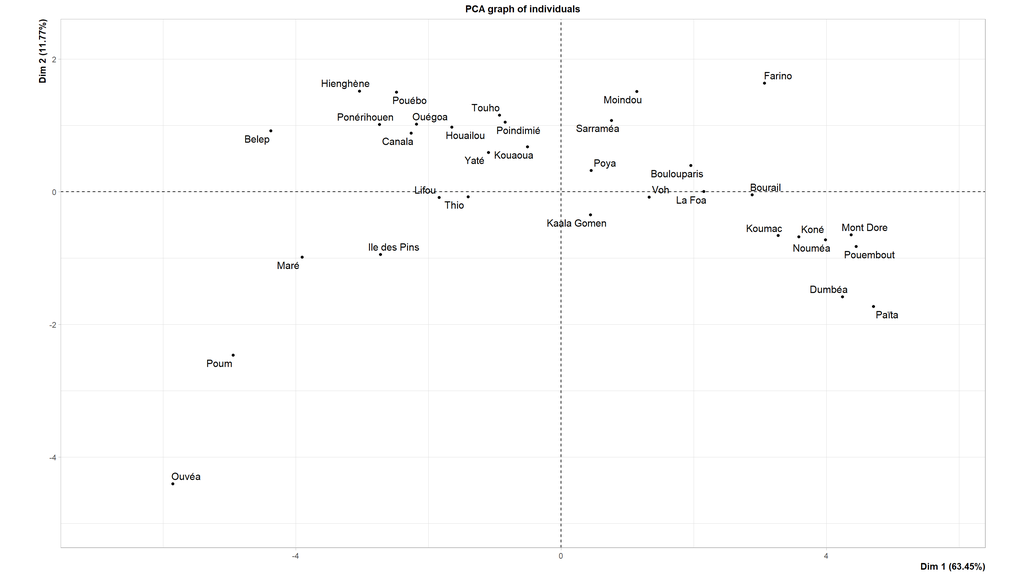

```r
pca_communes <- PCA(df_communes %>% select(-NEM, -NEM100, -COUNT), graph = FALSE)
plot(pca_communes)
```

```r
summary(pca_communes)
```

```
##
## Call:
## PCA(X = df_communes %>% select(-NEM, -NEM100, -COUNT), graph = FALSE)
##
##
## Eigenvalues
##                        Dim.1   Dim.2   Dim.3   Dim.4   Dim.5   Dim.6   Dim.7   Dim.8   Dim.9  Dim.10  Dim.11  Dim.12
## Variance               8.883   1.647   1.181   0.750   0.484   0.357   0.260   0.182   0.105   0.064   0.040   0.020
## % of var.             63.452  11.768   8.438   5.358   3.456   2.553   1.856   1.301   0.747   0.454   0.287   0.146
## Cumulative % of var.  63.452  75.220  83.658  89.016  92.472  95.025  96.881  98.182  98.929  99.382  99.670  99.815
##                       Dim.13  Dim.14
## Variance               0.016   0.010
## % of var.              0.114   0.071
## Cumulative % of var.  99.929 100.000
##
## Individuals (the 10 first)
##                  Dist    Dim.1    ctr   cos2    Dim.2    ctr   cos2    Dim.3    ctr   cos2
## Belep        |  5.437 | -4.376  6.533  0.648 |  0.918  1.550  0.029 |  2.160 11.969  0.158 |
## Boulouparis  |  2.867 |  1.957  1.307  0.466 |  0.400  0.294  0.019 |  0.312  0.249  0.012 |
## Bourail      |  3.004 |  2.879  2.828  0.919 | -0.044  0.004  0.000 |  0.556  0.792  0.034 |
## Canala       |  2.717 | -2.262  1.745  0.693 |  0.883  1.435  0.106 | -0.767  1.510  0.080 |
## Dumbéa       |  4.726 |  4.242  6.139  0.806 | -1.583  4.611  0.112 |  0.067  0.012  0.000 |
## Farino       |  4.191 |  3.064  3.203  0.535 |  1.639  4.938  0.153 |  1.287  4.251  0.094 |
## Hienghène    |  4.281 | -3.043  3.158  0.505 |  1.519  4.245  0.126 | -1.493  5.715  0.122 |
## Houailou     |  2.078 | -1.650  0.929  0.631 |  0.976  1.751  0.221 | -0.271  0.188  0.017 |
## Ile des Pins |  3.604 | -2.724  2.532  0.572 | -0.947  1.649  0.069 |  0.127  0.041  0.001 |
## Kaala Gomen  |  1.954 |  0.441  0.066  0.051 | -0.346  0.221  0.031 | -0.302  0.235  0.024 |
##
## Variables (the 10 first)
##                 Dim.1    ctr   cos2    Dim.2    ctr   cos2    Dim.3    ctr   cos2
## ELEC         |  0.532  3.191  0.283 | -0.219  2.910  0.048 |  0.712 42.934  0.507 |
## EAU          |  0.461  2.395  0.213 |  0.627 23.842  0.393 |  0.184  2.872  0.034 |
## BATI         |  0.671  5.069  0.450 |  0.532 17.189  0.283 | -0.351 10.421  0.123 |
## BAIN         |  0.857  8.267  0.734 |  0.311  5.883  0.097 | -0.139  1.629  0.019 |
## WC           |  0.867  8.467  0.752 |  0.327  6.505  0.107 | -0.163  2.262  0.027 |
## MAL          |  0.917  9.468  0.841 | -0.099  0.593  0.010 | -0.007  0.004  0.000 |
## REFRI        |  0.913  9.383  0.833 | -0.004  0.001  0.000 |  0.206  3.601  0.043 |
## CLIM         |  0.915  9.421  0.837 | -0.245  3.631  0.060 |  0.068  0.389  0.005 |
## CHOS         |  0.902  9.161  0.814 | -0.231  3.233  0.053 |  0.093  0.731  0.009 |
## TFIXE        |  0.931  9.752  0.866 | -0.182  2.012  0.033 |  0.110  1.026  0.012 |
```

### AFC de l’équipement des ménages par commune

Avec *l’Analyse Factorielle des Correspondances* (AFC) on va pouvoir representer graphiquement les communes et les 14 variables dans un même espace. On distingue *sur les 2 axes principaux* les groupes de variables suivants, qui sont aussi visibles sur le cercle des correspondances de l’ACP (non représenté) :

- `CLIM`, `TFIXE`, `INTER` et `CHOS` qui donnent du poids au premier axe, proches du Grand Nouméa et de Pouembout,
- un groupe `REFRI`, `ELEC`, `BAIN`, `WC`, `EAU` et `BATI` proches du profil moyen, `MAL` s’échappant un peu, `VOIT` est peu discriminant et proche de ce groupe,
- le transport avec `DEROU` et `BATO` qui contribuent largement au 2ème axe.

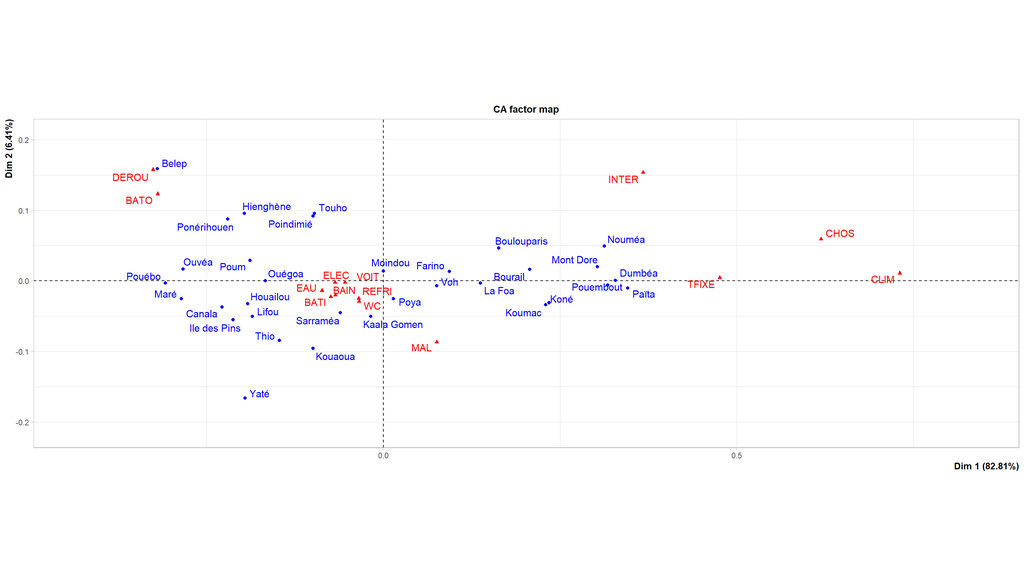

```r
ca_commune <- CA(df_communes %>% select(-NEM, -NEM100, -COUNT), graph = FALSE)
plot(ca_commune)
```

```r
summary(ca_commune)
```

```
##
## Call:
## CA(X = df_communes %>% select(-NEM, -NEM100, -COUNT), graph = FALSE)
##
## The chi square of independence between the two variables is equal to 16.1 (p-value =  1 ).
##
## Eigenvalues
##                        Dim.1   Dim.2   Dim.3   Dim.4   Dim.5   Dim.6   Dim.7   Dim.8   Dim.9  Dim.10  Dim.11  Dim.12
## Variance               0.046   0.004   0.002   0.001   0.001   0.001   0.001   0.000   0.000   0.000   0.000   0.000
## % of var.             82.810   6.414   3.522   2.097   1.569   1.245   1.005   0.646   0.284   0.239   0.092   0.053
## Cumulative % of var.  82.810  89.224  92.746  94.843  96.412  97.657  98.662  99.309  99.593  99.832  99.925  99.977
##                       Dim.13
## Variance               0.000
## % of var.              0.023
## Cumulative % of var. 100.000
##
## Rows (the 10 first)
##                Iner*1000    Dim.1    ctr   cos2    Dim.2    ctr   cos2    Dim.3    ctr   cos2
## Belep        |     3.711 | -0.320  6.049  0.752 |  0.159 19.265  0.186 |  0.052  3.703  0.020 |
## Boulouparis  |     1.322 |  0.163  1.964  0.686 |  0.046  2.053  0.056 |  0.085 12.632  0.188 |
## Bourail      |     1.558 |  0.207  3.179  0.942 |  0.016  0.252  0.006 |  0.043  3.263  0.041 |
## Canala       |     1.509 | -0.228  3.051  0.933 | -0.037  1.034  0.024 | -0.005  0.031  0.000 |
## Dumbéa       |     3.898 |  0.328  8.146  0.965 |  0.001  0.001  0.000 | -0.006  0.056  0.000 |
## Farino       |     0.618 |  0.093  0.658  0.491 |  0.013  0.172  0.010 |  0.012  0.248  0.008 |
## Hienghène    |     1.546 | -0.197  2.291  0.684 |  0.095  6.964  0.161 | -0.066  6.155  0.078 |
## Houailou     |     1.115 | -0.192  2.264  0.937 | -0.032  0.825  0.026 | -0.005  0.037  0.001 |
## Ile des Pins |     1.448 | -0.213  2.602  0.830 | -0.055  2.254  0.056 |  0.011  0.171  0.002 |
## Kaala Gomen  |     0.185 | -0.018  0.021  0.053 | -0.050  2.114  0.408 | -0.019  0.578  0.061 |
##
## Columns (the 10 first)
##                Iner*1000    Dim.1    ctr   cos2    Dim.2    ctr   cos2    Dim.3    ctr   cos2
## ELEC         |     0.924 | -0.068  1.041  0.520 | -0.002  0.015  0.001 |  0.015  1.110  0.024 |
## EAU          |     1.102 | -0.087  1.771  0.742 | -0.014  0.570  0.018 | -0.021  2.483  0.044 |
## BATI         |     0.874 | -0.075  1.312  0.693 | -0.022  1.534  0.063 | -0.015  1.195  0.027 |
## BAIN         |     0.663 | -0.068  1.082  0.753 | -0.020  1.206  0.065 | -0.007  0.239  0.007 |
## WC           |     0.450 | -0.034  0.266  0.273 | -0.029  2.425  0.193 | -0.005  0.130  0.006 |
## MAL          |     1.457 |  0.075  1.051  0.333 | -0.087 17.930  0.440 | -0.002  0.026  0.000 |
## REFRI        |     0.294 | -0.035  0.269  0.421 | -0.025  1.712  0.208 | -0.004  0.085  0.006 |
## CLIM         |    14.069 |  0.731 28.786  0.945 |  0.011  0.082  0.000 |  0.131 21.769  0.030 |
## CHOS         |     8.611 |  0.620 16.719  0.896 |  0.059  1.964  0.008 |  0.065  4.333  0.010 |
## TFIXE        |     8.340 |  0.476 16.460  0.911 |  0.005  0.019  0.000 |  0.036  2.162  0.005 |
```

### AFC de l’équipement des ménages par CSP de l’ensemble des individus actifs

On utilise la même méthode AFC mais cette fois entre équipement et catégories socio professionnelle (8 postes) de *l’ensemble des individus actifs de la BI* (pas seulement les référents de ménages). Pour cela, on joint sur la BI 2019 pour porter, les informations de logements seront *dupliquées* pour tous ses occupants actifs. On définit ici *actif* comme un individu avec une CSP autre que *retraités* (7) et *autres personnes sans activité professionnelle* (8). On commence par charge la BI 2019.

```r
# on va regrouper les communautés en 5 classes, correspondant à celles
# figurant au titre iv) de l'article 1 de l'arêté du 10/09/21 relatif à la diffusion du RP 2019

map_reth <- function(val) {
  case_when(
    val == "1" ~ "Kanake",
    val == "2" | val == "C" ~ "Européenne/Calédonienne",
    val == "7" ~ "Wallisienne/Futunienne",
    val == "M" ~ "Métis",
    TRUE ~ "Autre"
  )
}

bi19_r <- read_csv2("./src-rp/BI2019.csv") %>%
  filter(CS8 <= 6) %>%
  mutate(
    IDLOG = paste(NC, DIST, RADR, RLOG, sep = "-"),
    ETH = map_reth(RETH)
  )

# on oublie les erreurs et on joint
bl19_bi19 <- merge(bl19, bi19_r, by = "IDLOG", suffixes = c("_BL", "_BI"))
```

On a gardé ainsi 111467 individus de la BI 2019, on transforme les données et on caclule l’AFC.

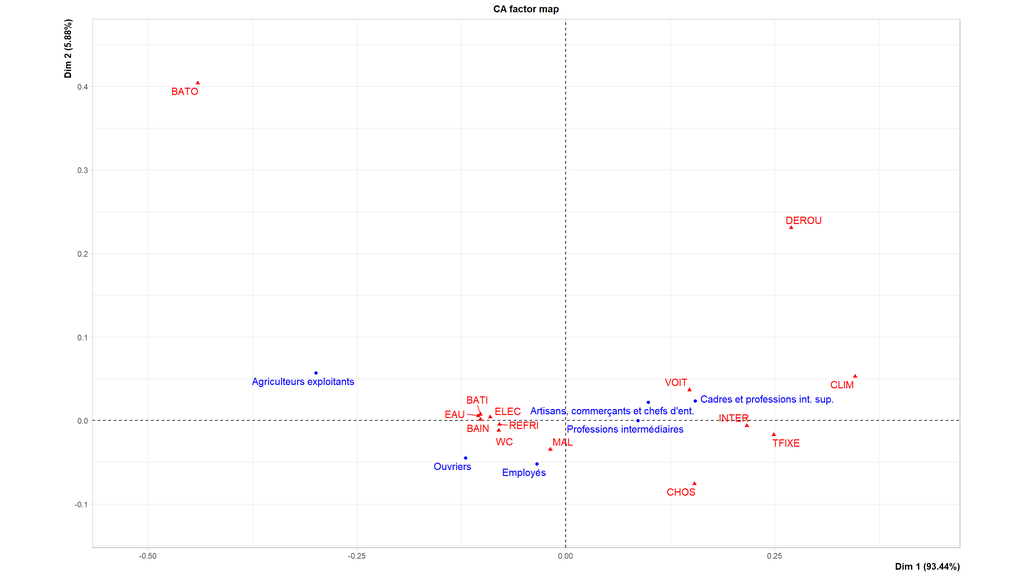

```r
cs8m_labels <- c(
  "Agriculteurs exploitants",
  "Artisans, commerçants et chefs d'ent.",
  "Cadres et professions int. sup.",
  "Professions intermédiaires",
  "Employés",
  "Ouvriers",
  "Retraités",
  "Autres pers. sans activité pro."
)

# CS8 est la variable CSP dans la BI, CS8M celle dans la BL
df_cs8m_bi <- bl19_bi19 %>%
  select(CS8, ELEC, EAU, BATI, BAIN, WC, MAL, REFRI, CLIM, CHOS, TFIXE, INTER, VOIT, BATO, DEROU) %>%
  group_by(CS8) %>%
  summarise_all(
    mean
  ) %>%
  mutate(
    CS8 = factor(cs8m_labels[1:6])
  ) %>%
  column_to_rownames("CS8")

ca_csm_bi <- CA(df_cs8m_bi, graph = FALSE)
plot(ca_csm_bi)
```

On retrouve sensiblement les mêmes groupements de variables d’équipement sur un premier axe avec 93.4% de variance et un second marqué par la mobilité avec 5.9% d’inertie.

- le groupe `CLIM`, `TFIXE`, `CHOS`, `INTER` et `VOIT` est à proximité des CSP+, PI et artisans, qui tous les deux marquent le premier axe factoriel,
- le groupe `REFRI`, `ELEC`, `BAIN`, `MAL`, `WC` et `EAU` est proche du vers le profil moyen,
- `DEROU` et `BATO` sont des marqueurs très fort des deux axes.

```r
df_cs8m_bi
```

```
##                                        ELEC   EAU  BATI  BAIN    WC   MAL REFRI  CLIM  CHOS TFIXE INTER  VOIT   BATO
## Agriculteurs exploitants              0.888 0.920 0.920 0.917 0.853 0.683 0.855 0.142 0.130 0.195 0.282 0.310 0.0715
## Artisans, commerçants et chefs d'ent. 0.975 0.975 0.979 0.987 0.983 0.951 0.979 0.657 0.358 0.681 0.816 0.630 0.0428
## Cadres et professions int. sup.       0.991 0.990 0.992 0.992 0.992 0.971 0.989 0.771 0.384 0.754 0.907 0.718 0.0312
## Professions intermédiaires            0.983 0.982 0.987 0.991 0.988 0.958 0.982 0.612 0.332 0.663 0.817 0.646 0.0263
## Employés                              0.969 0.975 0.976 0.985 0.977 0.924 0.967 0.410 0.313 0.517 0.623 0.458 0.0188
## Ouvriers                              0.942 0.967 0.959 0.980 0.968 0.885 0.945 0.285 0.278 0.400 0.502 0.428 0.0309
##                                        DEROU
## Agriculteurs exploitants              0.0154
## Artisans, commerçants et chefs d'ent. 0.0370
## Cadres et professions int. sup.       0.0410
## Professions intermédiaires            0.0293
## Employés                              0.0148
## Ouvriers                              0.0124
```

### AFC de l’équipement des ménages par niveau de diplôme de l’ensemble des individus actifs

Cette fois-ci on fait l’analyse par catégorie de diplômes des individus de la BI, avec une allure assez semblable au final constitué des mêmes groupes de variables.

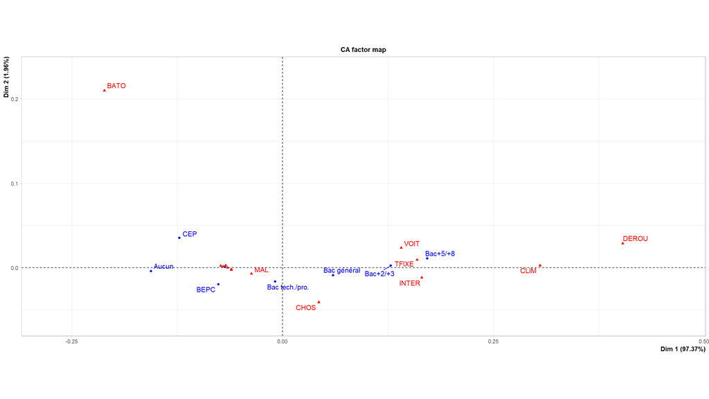

```r
diplm_labels <- c("Aucun", "CEP", "BEPC", "CAP/BEP", "Bac général", "Bac tech./pro.", "Bac+2/+3", "Bac+5/+8")

# DIPLR est la variable de diplôme dans la BI, DIPLM celle dans la BL
df_diplm_bi <- bl19_bi19 %>%
  select(DIPLR, ELEC, EAU, BATI, BAIN, WC, MAL, REFRI, CLIM, CHOS, TFIXE, INTER, VOIT, BATO, DEROU) %>%
  group_by(DIPLR) %>%
  summarise_all(
    mean
  ) %>%
  mutate(
    DIPLR = factor(diplm_labels)
  ) %>%
  column_to_rownames("DIPLR")

ca_diplm_bi <- CA(df_diplm_bi, graph = FALSE)
plot(ca_diplm_bi)
```

On voit que la représentation est encore très franche, avec

- une premier axe qui capture 97.4% de la variance,
- les diplômes **sont parfaitement ordonnés selon la durée des études** sur le premier axe :
  - Aucun diplôme et CEP;
  - BEPC et CAP/BEP;
  - Bacs technologiques ou professionnel et généraux;
  - Bac+2/+3 et Bac+5/+8
- on retrouve les groupements similaires d’équipements,
- et également un poids important de la mobilité, sauf voiture.

```r
df_diplm_bi
```

```
##                 ELEC   EAU  BATI  BAIN    WC   MAL REFRI  CLIM  CHOS TFIXE INTER  VOIT   BATO   DEROU
## Aucun          0.932 0.960 0.951 0.971 0.949 0.852 0.932 0.242 0.261 0.363 0.450 0.365 0.0329 0.01046
## CEP            0.940 0.964 0.967 0.979 0.958 0.870 0.941 0.280 0.242 0.429 0.482 0.426 0.0469 0.00983
## BEPC           0.961 0.969 0.966 0.981 0.967 0.906 0.958 0.343 0.305 0.457 0.559 0.429 0.0260 0.01601
## CAP/BEP        0.952 0.967 0.964 0.979 0.966 0.897 0.950 0.352 0.294 0.455 0.560 0.466 0.0330 0.01587
## Bac général    0.980 0.981 0.985 0.991 0.987 0.951 0.980 0.554 0.336 0.628 0.760 0.572 0.0245 0.02263
## Bac tech./pro. 0.974 0.976 0.980 0.986 0.982 0.937 0.974 0.443 0.312 0.534 0.664 0.506 0.0228 0.01603
## Bac+2/+3       0.986 0.985 0.991 0.993 0.993 0.966 0.986 0.683 0.362 0.697 0.859 0.668 0.0276 0.03241
## Bac+5/+8       0.990 0.989 0.991 0.993 0.994 0.973 0.990 0.763 0.361 0.760 0.919 0.722 0.0269 0.04238
```

### AFC de l’équipement des ménages par ethnie de l’ensemble des individus actifs

Cette fois enfin on fait l’analyse par groupe ethnique des individus de la BI et on s’abstiendra de toute autre commentaire.

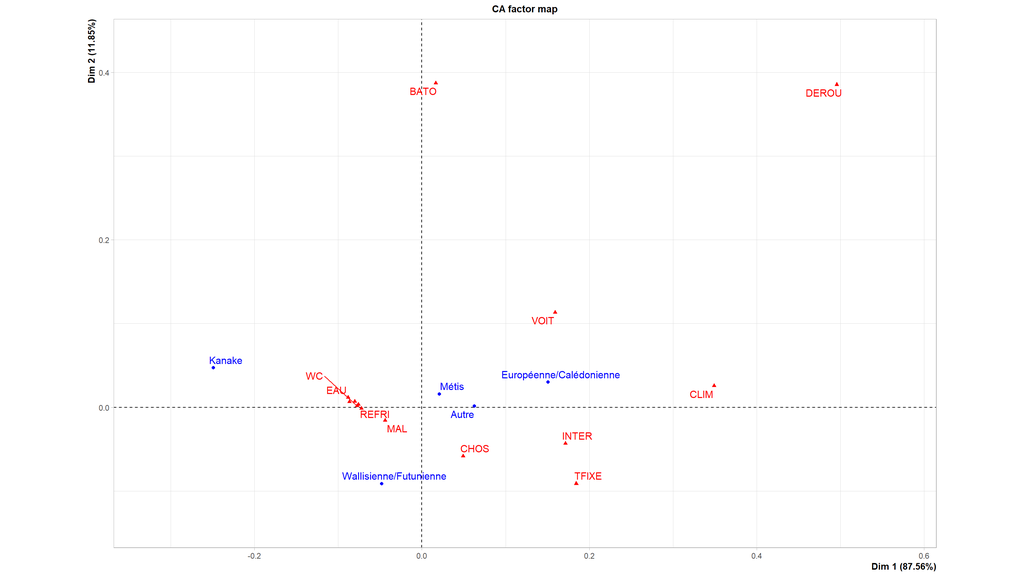

```r
# DIPLR est la variable de diplôme dans la BI, DIPLM celle dans la BL
df_eth_bi <- bl19_bi19 %>%
  select(ETH, ELEC, EAU, BATI, BAIN, WC, MAL, REFRI, CLIM, CHOS, TFIXE, INTER, VOIT, BATO, DEROU) %>%
  group_by(ETH) %>%
  summarise_all(
    mean
  ) %>%
  column_to_rownames("ETH")

df_eth_bi <- CA(df_eth_bi, graph = FALSE)
plot(df_eth_bi)
```

```r
df_eth_bi
```

```
## **Results of the Correspondence Analysis (CA)**
## The row variable has  5  categories; the column variable has 14 categories
## The chi square of independence between the two variables is equal to 0.911 (p-value =  1 ).
## *The results are available in the following objects:
##
##    name              description
## 1  "$eig"            "eigenvalues"
## 2  "$col"            "results for the columns"
## 3  "$col$coord"      "coord. for the columns"
## 4  "$col$cos2"       "cos2 for the columns"
## 5  "$col$contrib"    "contributions of the columns"
## 6  "$row"            "results for the rows"
## 7  "$row$coord"      "coord. for the rows"
## 8  "$row$cos2"       "cos2 for the rows"
## 9  "$row$contrib"    "contributions of the rows"
## 10 "$call"           "summary called parameters"
## 11 "$call$marge.col" "weights of the columns"
## 12 "$call$marge.row" "weights of the rows"
```

## Distribution et évolution du NEM

### Par province

On représente les variations du NEM100 par province sur chacune des années de recensement avec une représentation *violin plot* qui permet de comparer les distributions des valeurs entre classes. On va comparer les profils sur chacun des 3 RP. On commence par fusionner tous les BL avec une nouvelle colonne d’années puis on trace un *violin plot* pour chaque province et chaque année.

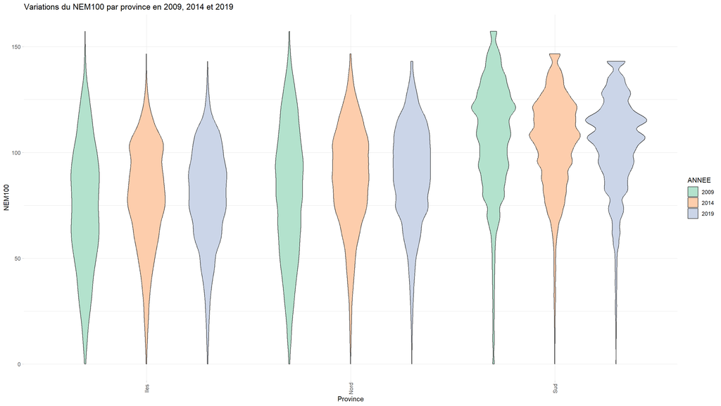

```r
bl_merged <- rbind(
  bl09 %>% mutate(ANNEE = "2009"),
  bl14 %>% mutate(ANNEE = "2014"),
  bl19 %>% mutate(ANNEE = "2019")
)

ggplot(bl_merged, aes(x = PROV, y = NEM100, fill = ANNEE)) +
  ggtitle("Variations du NEM100 par province en 2009, 2014 et 2019") +
  xlab("Province") +
  scale_fill_brewer(palette = "Pastel2") +
  geom_violin()
```

On constate une tendance à **l’élévation du NEM dans la province nord et celle des îles** et à **la réduction de l’écart-type au sein de toutes les provinces**, correspondant à un ré-équilibrage des provinces et une réduction des inégalités. Ceci est vérifié par les valeurs numériques ci-après. On remarque en particulier *que l’élévation du NEM et la réduction de l’écart-type* sont **très marqué entre 2009 et 2014** mais **moins entre 2014 et 2019**. On rappelle que la moyenne NC du NEM100 a été recentrée sur la valeur 100. L’écart-type général étant respectivement de 30.6, 24.2 et 23.5 en 2009, 2014 et 2019.

```r
bl_merged %>%
  select(PROV, NEM100, ANNEE) %>%
  group_by(PROV, ANNEE) %>%
  summarise_all(list(mean = mean, sd = sd)) %>%
  pivot_wider(names_from = ANNEE, values_from = c(mean, sd))
```

```
## # A tibble: 3 × 7
## # Groups:   PROV [3]
##   PROV  mean_2009 mean_2014 mean_2019 sd_2009 sd_2014 sd_2019
##   <chr>     <dbl>     <dbl>     <dbl>   <dbl>   <dbl>   <dbl>
## 1 Iles       73.9      78.8      78.8    29.4    24.5    23.6
## 2 Nord       80.7      88.0      89.3    31.4    24.5    23.6
## 3 Sud       106.      104.      104.     27.6    22.4    21.9
```

### Par commune

On commence par charger les trois BL que l’on joint avec les communes.

```r
bl09_comm <- bl09 %>%
  merge(communes, by.x = "NC", by.y = 0) %>%
  filter(!is.na(TYPE)) %>%
  select(NC, IRISUNC, NEM100, NOM_COMMUNE, TYPE)
bl09_comm$ANNEE <- "2009"

bl14_comm <- bl14 %>%
  merge(communes, by.x = "NC", by.y = 0) %>%
  filter(!is.na(TYPE)) %>%
  select(NC, IRISUNC, NEM100, NOM_COMMUNE, TYPE)
bl14_comm$ANNEE <- "2014"

bl19_comm <- bl19 %>%
  merge(communes, by.x = "NC", by.y = 0) %>%
  filter(!is.na(TYPE)) %>%
  select(NC, IRISUNC, NEM100, NOM_COMMUNE, TYPE)
bl19_comm$ANNEE <- "2019"

bl_comm <- rbind(bl09_comm, bl14_comm, bl19_comm)
```

Ensuite, on représente l’évolution de la distribution des NEM100 en 2009, 2014 et 2019 avec la même représentation que pour les provinces.

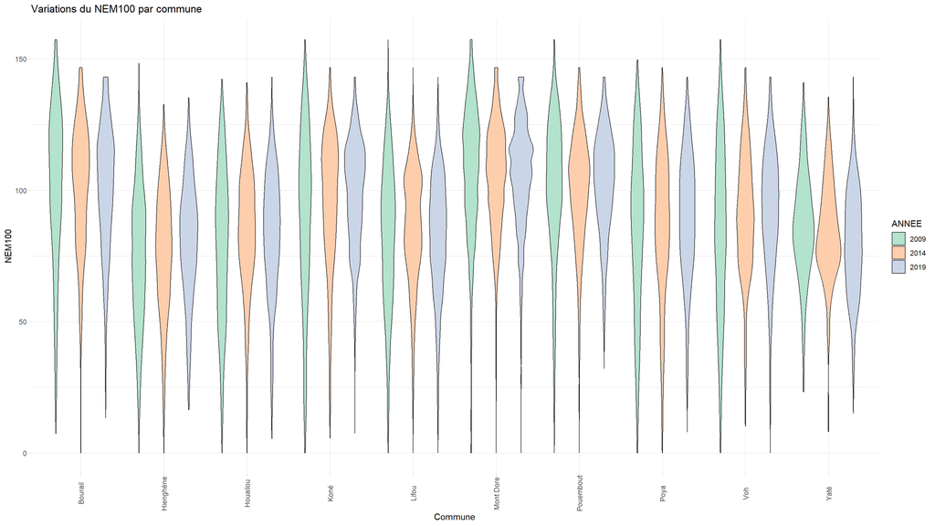

```r
ggplot(bl_comm, aes(x = NOM_COMMUNE, y = NEM100, fill = ANNEE)) +
  ggtitle("Variations du NEM100 par commune") +
  xlab("Commune") +
  scale_fill_brewer(palette = "Pastel2") +
  geom_violin()
```

L’allure générale est encore à la réduction des inégalités, mais au niveau des communes, on constate certains variations opposées, en particulier sur Yaté. La variation entre 2009 et 2019 est calculée en % pour la moyenne du NEM100 et en valeur absolue pour l’écart type. Les valeurs numériques sont données ci-après.

```r
bl_comm %>%
  select(NOM_COMMUNE, NEM100, ANNEE) %>%
  group_by(NOM_COMMUNE, ANNEE) %>%
  summarise_all(list(mean = mean, sd = sd)) %>%
  pivot_wider(names_from = ANNEE, values_from = c(mean, sd)) %>%
  mutate(
    diff_pc_mean_2019_2009 = 100 * (mean_2019 / mean_2009 - 1),
    diff_abs_sd_2019_2009 = sd_2019 - sd_2009
  )
```

```
## # A tibble: 10 × 9
## # Groups:   NOM_COMMUNE [10]
##    NOM_COMMUNE mean_2009 mean_2014 mean_2019 sd_2009 sd_2014 sd_2019 diff_pc_mean_2019_2009 diff_abs_sd_2019_2009
##    <chr>           <dbl>     <dbl>     <dbl>   <dbl>   <dbl>   <dbl>                  <dbl>                 <dbl>
##  1 Bourail         101.      101.      101.     30.4    24.3    24.0                -0.178                -6.38
##  2 Hienghène        74.6      76.6      80.8    25.9    23.6    22.4                 8.29                 -3.54
##  3 Houailou         79.5      84.5      83.4    28.6    23.2    23.4                 4.91                 -5.22
##  4 Koné             90.1      95.1      98.2    32.5    25.5    20.6                 8.99                -11.9
##  5 Lifou            82.5      85.5      82.6    27.2    22.1    22.7                 0.0796               -4.48
##  6 Mont Dore       107.      105.      105.     26.4    21.3    20.5                -1.14                 -5.82
##  7 Pouembout       101.       99.6     102.     26.6    21.9    19.5                 1.63                 -7.02
##  8 Poya             84.9      86.3      89.7    31.3    27.4    23.6                 5.67                 -7.67
##  9 Voh              84.8      90.0      91.9    31.5    23.3    23.3                 8.34                 -8.23
## 10 Yaté             86.3      83.9      79.8    20.2    18.6    20.2                -7.50                  0.0605
```

### Infra communes sur VKPP en 2019

Enfin, on représente la distribution du NEM100 sur les IRIS de VKPP. On constate une **importante variation intra-communale** qui ne saurait être expliquée par la distance à la mine ou à l’usine, mais plutôt par leur homogénéité sociale. On ajoute sur cette représentation moyenne (trait) et mediane (point).

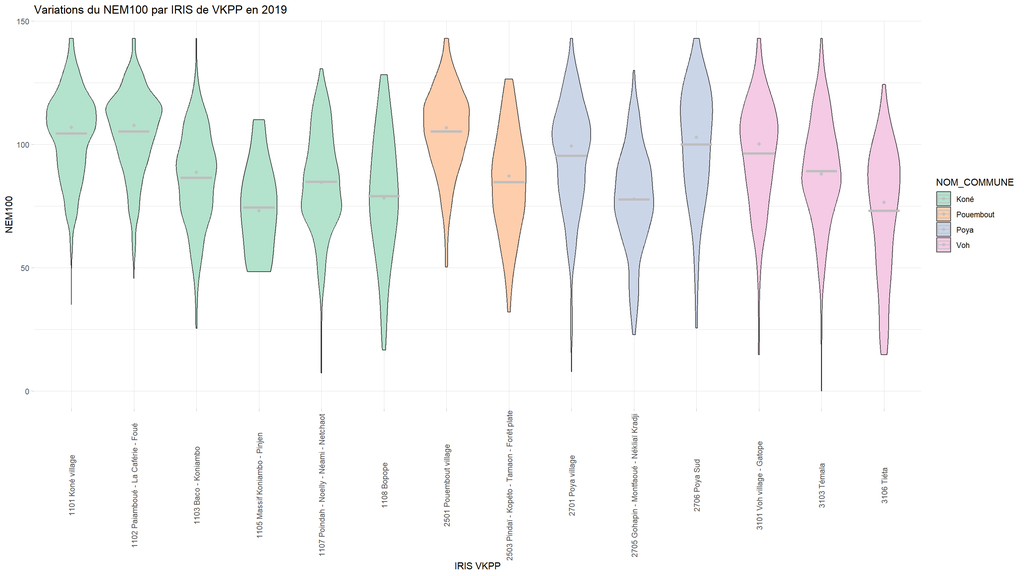

```r
# Voh (31), Koné (11), Pouembout (25), Poya (27)
vkpp_communes <- c("31", "11", "25", "27")

bl19_iris_com <- bl19 %>%
  merge(y = communes, by.x = "NC", by.y = 0) %>%
  filter(NC %in% vkpp_communes) %>%
  merge(y = iris_csv, by.x = "IRISUNC", by.y = "IRIS")

ggplot(bl19_iris_com, aes(x = paste(IRISUNC, LIB_IRIS), y = NEM100, fill = NOM_COMMUNE)) +
  ggtitle("Variations du NEM100 par IRIS de VKPP en 2019 ") +
  xlab("IRIS VKPP") +
  scale_fill_brewer(palette = "Pastel2") +
  geom_violin() +
  stat_summary(fun = "mean", geom = "crossbar", width = 0.5, color = "grey", alpha = 0.8) +
  stat_summary(fun = "median", geom = "point", color = "grey", alpha = 0.8)
```

## Représentations spatiales du NEM

On charge le shapefile des IRIS pour pouvoir générer des cartes et on joint la définition géographique au NEM via les codes des IRIS. On étoffe le jeu de données avec quelques indicateurs synthétiques par IRIS :

- `COUNT_DIFF_0919` : pourcentage relatif d’évolution 2009-2019 du nombre de logements,
- `NEM100_MEAN_PC_DIFF_0919` : pourcentage relatif d’évolution 2009-2019 de la moyenne du NEM base 100,
- `NEM100_SD_ABS_DIFF_0919` : évolution en valeur absolue 2009-2019 de *l’écart-type* du NEM base 100,
- `NEM100_SD_ABS_DIFF_0914` : idem entre 2009 et 2014,
- `NEM100_SD_ABS_DIFF_1419` : idem entre 2014 et 2019.

On rappelle qu’on ne compte *que les résidences principales* de la BL.

```r
# communes du Grand Nouméa : NOUMEA (18), PAITA (21), MONT DORE (17), DUMBEA (05)
grand_noumea <- c("05", "17", "18", "21")
iris <- st_read("src-iris/iris0914unc.shp") %>%
  select(COMM, CODE_IRIS, LIB_IRIS) %>%
  merge(y = nem_iris, by.x = "CODE_IRIS", by.y = "IRISUNC", all.x = TRUE) %>%
  merge(y = communes, by.x = "COMM", by.y = 0) %>%
  mutate(
    COUNT_DIFF_0919 = 100 * ((COUNT_19 / COUNT_09) - 1),
    NEM100_MEAN_PC_DIFF_0919 = 100 * ((NEM100_MEAN_19 / NEM100_MEAN_09) - 1),
    NEM100_SD_ABS_DIFF_0919 = NEM100_SD_19 - NEM100_SD_09,
    NEM100_SD_ABS_DIFF_0914 = NEM100_SD_14 - NEM100_SD_09,
    NEM100_SD_ABS_DIFF_1419 = NEM100_SD_19 - NEM100_SD_14,
  )
```

Globalement, il y a eu une évolution 25.023% du nombre de résidences principales en NC qui passe de 72637 en 2009 à 90813 en 2019. Pour une meilleure lisibilité, on sépare la carte du Grand Nouméa (GN) du reste du territoire.

### Nombre de logements par IRIS

On voit sur le GN une évolution importante des communes du GN hors Nouméa, en particulier Dumbéa. Ici, on sépare les classes avec la méthode `jenks`.

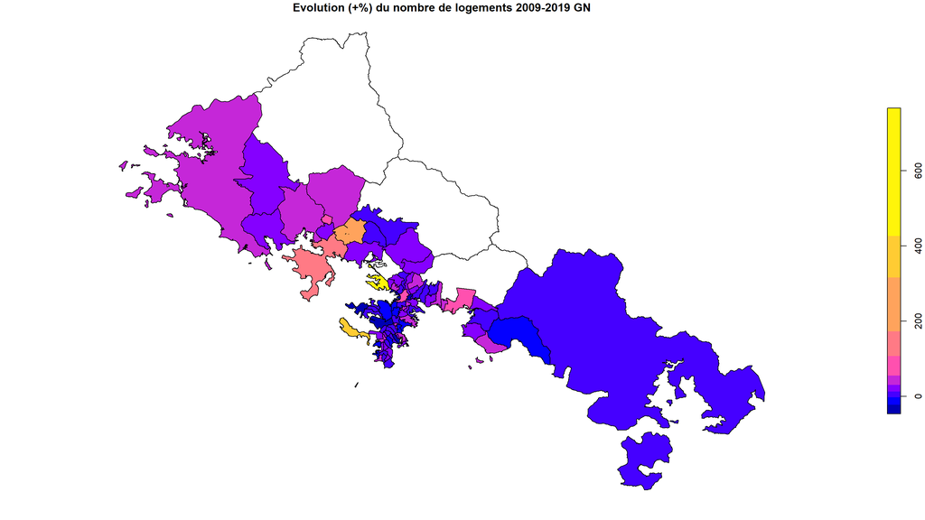

```r
iris %>%
  filter(COMM %in% grand_noumea) %>%
  select(COUNT_DIFF_0919) %>%
  plot(
    main = "Evolution (+%) du nombre de logements 2009-2019 GN",
    axes = FALSE,
    key.pos = 4,
    breaks = "jenks",
    nbreaks = 10
  )
```

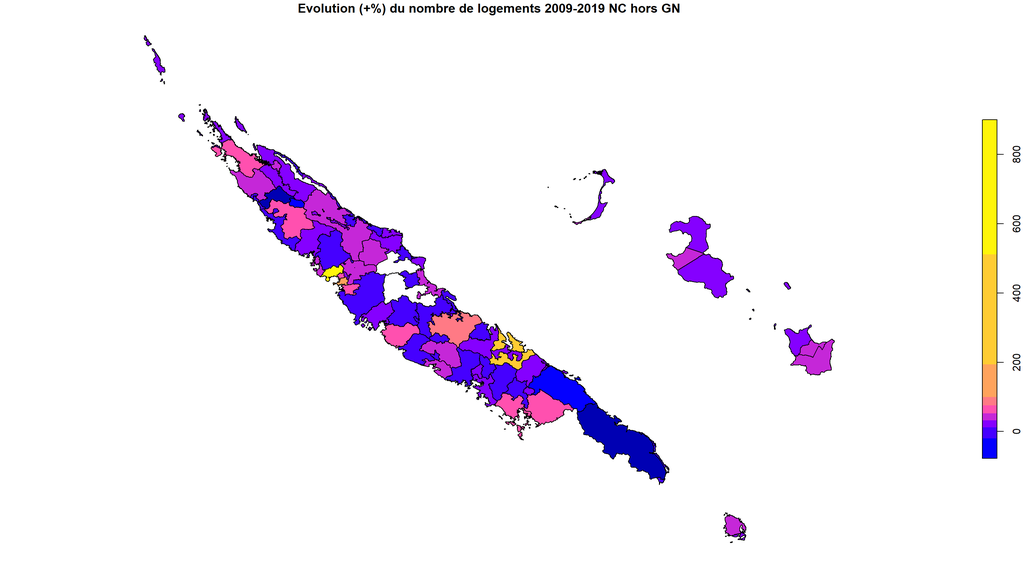

```r
iris %>%
  filter(COMM %notin% grand_noumea) %>%
  select(COUNT_DIFF_0919) %>%
  plot(
    main = "Evolution (+%) du nombre de logements 2009-2019 NC hors GN",
    axes = FALSE,
    key.pos = 4,
    breaks = "jenks",
    nbreaks = 10
  )
```

En affichant les premiers résultats, on constate une forte évolution sur certains IRIS du Grand Nouméa dont Nouville et sur Koné (commune n°11), avec aussi la présence de Canala (n°04) et Houailou (n°08) à l’est. Attention toutefois *aux effectifs qui peuvent être **très** faibles* et qui expliquent certaines augmentation très importantes. Ci-dessous, le top 20 des IRIS où le nombre de logements augmente le plus entre 2009 et 2019.

```r
iris %>%
  arrange(desc(COUNT_DIFF_0919)) %>%
  select(CODE_IRIS, LIB_IRIS, NOM_COMMUNE, COUNT_DIFF_0919, COUNT_09, COUNT_19) %>%
  st_drop_geometry() %>%
  column_to_rownames("CODE_IRIS") %>%
  head(20)
```

```
##                                 LIB_IRIS NOM_COMMUNE COUNT_DIFF_0919 COUNT_09 COUNT_19
## 1105            Massif Koniambo - Pinjen        Koné           900.0        2       20
## 0510                    Dumbéa/mer Ouest      Dumbéa           766.4      214     1854
## 0404                            Mé Kwaré      Canala           511.1        9       55
## 1823                            Nouville      Nouméa           426.3      262     1379
## 2103               Nogouta-Les 3 Vallées       Païta           315.9      208      865
## 1102       Paiamboué - La Caférie - Foué        Koné           193.4      228      669
## 2110                    Savannah - Nouré       Païta           173.0      440     1201
## 0501               Coeur de ville urbain      Dumbéa           107.4      598     1240
## 0808           Kua - Néoua - Gwa Ruviano    Houailou           100.0       24       48
## 2102                         Scheffleras       Païta            99.3      449      895
## 1709                         Saint Louis   Mont Dore            75.6      225      395
## 0204                        Tomo-Ouinané Boulouparis            75.1      189      331
## 2706                            Poya Sud        Poya            73.1       52       90
## 0201                 Boulouparis village Boulouparis            68.2      434      730
## 2501                   Pouembout village   Pouembout            65.7      487      807
## 1006       Massif Ouazangou - Mont Kaala Kaala Gomen            63.2       19       31
## 1101                        Koné village        Koné            61.9      632     1023
## 2603            Bouarou - Pangaï - Naraï        Poum            61.4      127      205
## 1707                             Boulari   Mont Dore            55.4      543      844
## 1107 Poindah - Noelly - Néami - Netchaot        Koné            52.2      360      548
```

### Evolution du NEM moyen par IRIS

On va maintenant s’intéresser à l’évolution de la moyenne du NEM base 100 par IRIS entre 2009 et 2019, ici on colorie selon 10 déciles du NEM100.

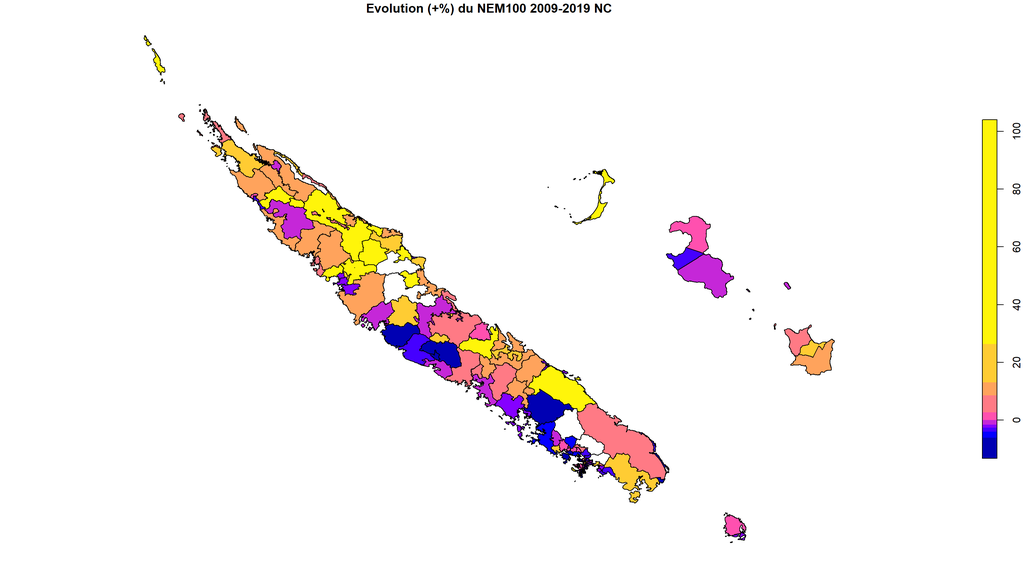

```r
plot(
  iris["NEM100_MEAN_PC_DIFF_0919"],
  main = "Evolution (+%) du NEM100 2009-2019 NC",
  axes = FALSE,
  key.pos = 4,
  breaks = "quantile",
  nbreaks = 10
)
```

```r
iris %>%
  arrange(desc(NEM100_MEAN_PC_DIFF_0919)) %>%
  select(NOM_COMMUNE, LIB_IRIS, CODE_IRIS, NEM100_MEAN_PC_DIFF_0919, NEM100_MEAN_09, NEM100_MEAN_19) %>%
  st_drop_geometry() %>%
  column_to_rownames("CODE_IRIS") %>%
  head(20)
```

```
##      NOM_COMMUNE                                         LIB_IRIS NEM100_MEAN_PC_DIFF_0919 NEM100_MEAN_09
## 1108        Koné                                           Bopope                    103.9           38.8
## 0502      Dumbéa                          Coeur de ville littoral                     75.2           30.5
## 2906        Thio                                          Borendy                     64.2           44.9
## 1823      Nouméa                                         Nouville                     58.6           57.8
## 0101       Belep                                            Bélep                     58.4           50.7
## 2303 Ponérihouen               Goyetta - Goa - Nébouéba - St Yves                     51.6           53.4
## 1206      Koumac                                  Piton de Pandop                     49.5           59.6
## 1105        Koné                         Massif Koniambo - Pinjen                     49.0           50.0
## 1004 Kaala Gomen                       Ouéholle - Ouémou - Kourou                     44.2           55.0
## 2001       Ouvéa                    Saint Joseph Gossanah Takedji                     40.7           45.7
## 2202   Poindimié                                      Tiéti - Tyé                     34.8           61.6
## 3302     Kouaoua                        Méa Mébara - Ouérou Pimet                     33.6           60.5
## 3003       Touho           Tiouandé - Ouanache - Congouma - Paola                     33.2           65.1
## 0705   Hienghène              Oué - Hawa - Ouen - Kout - Pwa Jilu                     31.5           48.8
```

[output cut: 27 more lines]

On constate, *avec cette échelle de couleur basée sur 10 quintiles*, une assez franche séparation Nord/Est versus Sud/Ouest

### Evolution de l’écart-type du NEM par IRIS

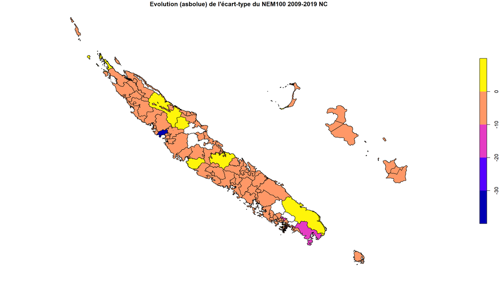

```r
plot(
  iris["NEM100_SD_ABS_DIFF_0919"],
  main = "Evolution (asbolue) de l'écart-type du NEM100 2009-2019 NC",
  axes = FALSE,
  key.pos = 4,
  breaks = "pretty",
  nbreaks = 5
)
```

L’écart type du NEM100 **a été considérable réduit sur l’ensemble du territoire**, sauf sur les IRIS ci-dessous. On rappelle que écart-type NC du NEM100 passe de 30.6 en 2009 à 24.2 en 2014 puis 23.5 en 2019, soit un différence de -7.08 points entre 2009 et 2019.

```r
iris %>%
  arrange(desc(NEM100_SD_ABS_DIFF_0919)) %>%
  select(NOM_COMMUNE, LIB_IRIS, CODE_IRIS, COUNT_19, NEM100_SD_ABS_DIFF_0919, NEM100_SD_09, NEM100_SD_19) %>%
  st_drop_geometry() %>%
  column_to_rownames("CODE_IRIS") %>%
  filter(NEM100_SD_ABS_DIFF_0919 > 0)
```

```
##      NOM_COMMUNE                            LIB_IRIS COUNT_19 NEM100_SD_ABS_DIFF_0919 NEM100_SD_09 NEM100_SD_19
## 1804      Nouméa                     Anse Vata Ouest      658                   5.113         17.8         22.9
## 0502      Dumbéa             Coeur de ville littoral      267                   3.234         20.0         23.2
## 0808    Houailou           Kua - Néoua - Gwa Ruviano       48                   2.893         21.5         24.4
## 0506      Dumbéa                        Jacarandas I      880                   2.087         16.6         18.6
## 2003       Ouvéa                               Mouli      160                   1.947         23.1         25.1
## 0504      Dumbéa                      Koutio érudits      629                   1.856         20.5         22.4
## 1844      Nouméa                              Kaméré      813                   1.069         17.8         18.9
## 1816      Nouméa                       Magenta Tours      716                   0.642         18.0         18.6
## 3202        Yaté                                Unia      177                   0.569         19.2         19.8
## 1841      Nouméa            Rivière Salée Nord Ouest      529                   0.544         20.7         21.2
## 1108        Koné                              Bopope       61                   0.540         25.1         25.6
## 1845      Nouméa           Tindu - Numbo - Koumourou      345                   0.485         26.4         26.9
## 2706        Poya                            Poya Sud       90                   0.463         23.1         23.6
## 3201        Yaté                 Waho Touaourou Goro      274                   0.302         20.3         20.6
## 2601        Poum                Poum village - Titch      262                   0.145         29.7         29.9
## 0705   Hienghène Oué - Hawa - Ouen - Kout - Pwa Jilu       24                   0.145         20.8         20.9
## 3203        Yaté      Ouinné Pourina Plaine des lacs        2                   0.108         21.4         21.5
```

En comparaison, on garde ici les variations les plus importantes.

```r
iris %>%
  arrange(NEM100_SD_ABS_DIFF_0919) %>%
  select(NOM_COMMUNE, LIB_IRIS, CODE_IRIS, COUNT_19, NEM100_SD_ABS_DIFF_0919, NEM100_SD_09, NEM100_SD_19) %>%
  st_drop_geometry() %>%
  column_to_rownames("CODE_IRIS") %>%
  head(10)
```

```
##      NOM_COMMUNE                         LIB_IRIS COUNT_19 NEM100_SD_ABS_DIFF_0919 NEM100_SD_09 NEM100_SD_19
## 1105        Koné         Massif Koniambo - Pinjen       20                  -35.74         54.4         18.6
## 0501      Dumbéa            Coeur de ville urbain     1240                  -15.35         34.7         19.4
## 1819      Nouméa                     Haut Magenta      820                  -13.48         33.4         19.9
## 1715   Mont Dore Mouirange - Grand Sud - Ile Ouen      116                  -13.00         36.1         23.1
## 1831      Nouméa                         PK 6 Sud      369                  -12.40         47.6         35.2
## 0514      Dumbéa              Nondoué La Couvelée      448                  -11.82         36.0         24.2
## 1710   Mont Dore                   La Coulée Nord      391                  -11.81         32.1         20.3
## 0305     Bourail                               Ny      267                   -9.68         28.1         18.5
## 3001       Touho                    Touho village      339                   -9.21         28.8         19.6
## 1712   Mont Dore                      Vallon Dore      793                   -9.20         31.0         21.8
```

On proccède similairement pour la différence d’écrt type par IRIS entre 2009 et 2014.

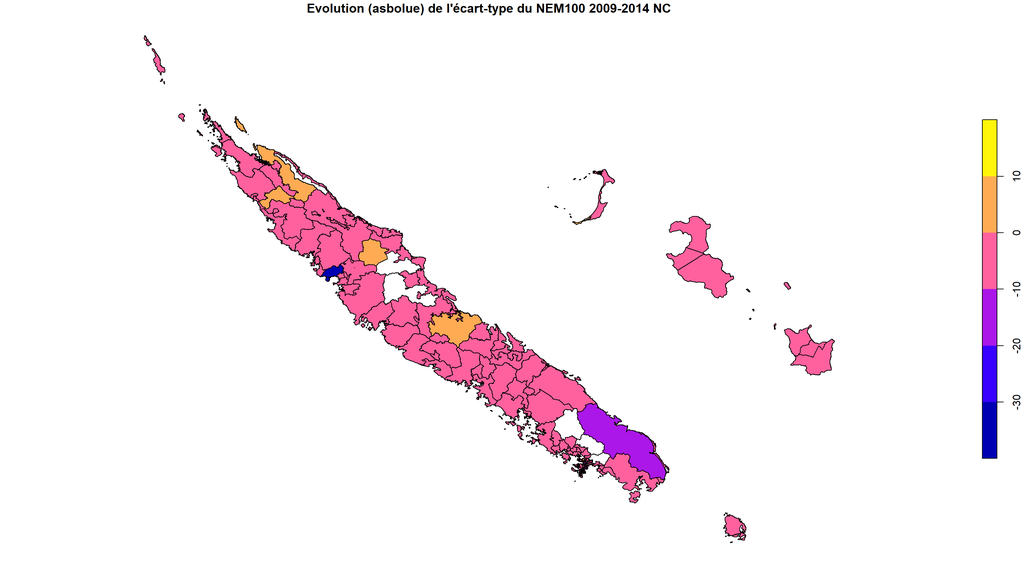

```r
plot(
  iris["NEM100_SD_ABS_DIFF_0914"],
  main = "Evolution (asbolue) de l'écart-type du NEM100 2009-2014 NC",
  axes = FALSE,
  key.pos = 4,
  breaks = "pretty",
  nbreaks = 5
)
```

On retrouve les IRIS où l’écart progresse :

```r
iris %>%
  arrange(desc(NEM100_SD_ABS_DIFF_0914)) %>%
  select(NOM_COMMUNE, LIB_IRIS, CODE_IRIS, COUNT_14, NEM100_SD_ABS_DIFF_0914, NEM100_SD_09, NEM100_SD_14) %>%
  st_drop_geometry() %>%
  column_to_rownames("CODE_IRIS") %>%
  filter(NEM100_SD_ABS_DIFF_0914 > 0)
```

```
##      NOM_COMMUNE                  LIB_IRIS COUNT_14 NEM100_SD_ABS_DIFF_0914 NEM100_SD_09 NEM100_SD_14
## 1804      Nouméa           Anse Vata Ouest      782                  11.943         17.8         29.7
## 0502      Dumbéa   Coeur de ville littoral      344                   8.016         20.0         28.0
## 0808    Houailou Kua - Néoua - Gwa Ruviano       76                   5.230         21.5         26.7
## 1902      Ouégoa               Pam - Tiari       67                   1.777         25.6         27.4
## 1206      Koumac           Piton de Pandop        3                   1.641         25.7         27.3
## 0506      Dumbéa              Jacarandas I      887                   1.145         16.6         17.7
## 1108        Koné                    Bopope       81                   1.144         25.1         26.2
## 1844      Nouméa                    Kaméré      824                   0.871         17.8         18.7
## 2003       Ouvéa                     Mouli      154                   0.411         23.1         23.5
## 0504      Dumbéa            Koutio érudits      604                   0.156         20.5         20.7
```

Et de même entre 2014 et 2019. Ici, des écart substantiels apparaissent sur beaucoup plus de communes, **attention au changement des classes de couleurs**.

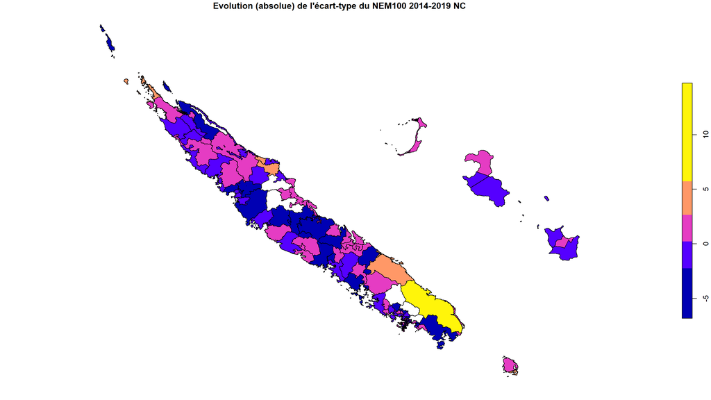

```r
plot(
  iris["NEM100_SD_ABS_DIFF_1419"],
  main = "Evolution (absolue) de l'écart-type du NEM100 2014-2019 NC",
  axes = FALSE,
  key.pos = 4,
  breaks = "jenks",
  nbreaks = 5
)
```

On appréciera mieux avec la liste :

```r
iris %>%
  arrange(desc(NEM100_SD_ABS_DIFF_1419)) %>%
  select(NOM_COMMUNE, LIB_IRIS, CODE_IRIS, COUNT_14, NEM100_SD_ABS_DIFF_1419, NEM100_SD_14, NEM100_SD_19) %>%
  st_drop_geometry() %>%
  column_to_rownames("CODE_IRIS") %>%
  filter(NEM100_SD_ABS_DIFF_1419 > 0)
```

```
##       NOM_COMMUNE                                         LIB_IRIS COUNT_14 NEM100_SD_ABS_DIFF_1419 NEM100_SD_14
## 3203         Yaté                   Ouinné Pourina Plaine des lacs       10                 14.7117         6.83
## 2601         Poum                             Poum village - Titch      230                  5.7275        24.15
## 0901 Ile des Pins                                              Vao      252                  4.5756        18.41
## 2901         Thio                                     Thio village      473                  4.3105        19.73
## 2906         Thio                                          Borendy       71                  4.1827        17.19
## 3003        Touho           Tiouandé - Ouanache - Congouma - Paola      143                  3.9390        18.27
## 1845       Nouméa                        Tindu - Numbo - Koumourou      457                  3.7117        23.19
## 3004        Touho                Koe - Kokingone - Tiwaka - Pombéi      148                  3.4207        18.49
## 0404       Canala                                         Mé Kwaré       25                  2.6608        21.94
## 2706         Poya                                         Poya Sud       87                  2.4441        21.15
## 2801     Sarraméa                                         Sarraméa      184                  2.3334        20.14
## 0801     Houailou                                 Houaïlou village      413                  2.2537        22.67
## 1004  Kaala Gomen                       Ouéholle - Ouémou - Kourou       80                  2.2476        20.47
## 1006  Kaala Gomen                    Massif Ouazangou - Mont Kaala       20                  2.2207        25.29
```

[output cut: 151 more lines]

## Influence de la distance à la mine

Dans cette partie, nous allons comparer les contributions de différents co-facteurs au NEM100 et en particulier l’influence du facteur de durée de trajet à la mine.

### Matrice de desserte

Pour celà on charge en premier *la matrice de desserte* qui à chaque IRIS fait correspondre la durée *médiane* (sur les noeuds routiers contenus dans l’IRIS) pour attendre le site minier (mine ou usine) *le plus proche*. Notons que ce calcul est fat essentiellement en SQL, voir le fichier `src-desserte/desserte.sql`.

On remarque que les IRIS de la province des îles, de l’île des Pins et de Belep disparaissent, car il n’y pas de routes, il reste ainsi 158 IRIS. Comme précédement, on supprimera les communes du GN de l’étude.

On donne un exemple de la structure de la table de desserte avec 20 IRIS pris au hasard.

```r
desserte <- read_csv("./src-desserte/duree_iris.csv") %>%
  select(code_iris, lib_iris, duree_usine, duree_centre) %>%
  mutate(
    duree_min = pmin(duree_usine, duree_centre)
  ) %>%
  column_to_rownames("code_iris")
desserte %>% sample_n(20)
```

```
##                                    lib_iris duree_usine duree_centre duree_min
## 0504                         Koutio érudits           8           40         8
## 0502                Coeur de ville littoral           6           41         6
## 0508                                Auteuil           9           40         9
## 2108                               Mont Mou          22           40        22
## 2103                  Nogouta-Les 3 Vallées          18           37        18
## 1816                          Magenta Tours           7           43         7
## 1845              Tindu - Numbo - Koumourou           9           47         9
## 1828                   Portes de Fer - Nord           4           40         4
## 2503 Pindaï - Kopéto - Tamaon - Forêt plate          51           43        43
## 1004             Ouéholle - Ouémou - Kourou          73           40        40
## 0404                               Mé Kwaré         120           18        18
## 2106             Tamoa Bangou Saint Laurent          26           24        24
## 0403          Gélima - Kuiné - Mia - Nakéty         114           14        14
## 0803                                  Waraï         127           19        19
## 1102          Paiamboué - La Caférie - Foué          22           40        22
## 1808                                Trianon           6           45         6
## 1812       Quartier Latin - Vallée du Génie           5           44         5
## 3103                                 Témala          26           27        26
## 1827                          Aérodrome Sud           6           41         6
## 2405         Massif du Panié - Mont Colnett         112           66        66
```

On represente la cartes des distances à l’usine des IRIS.

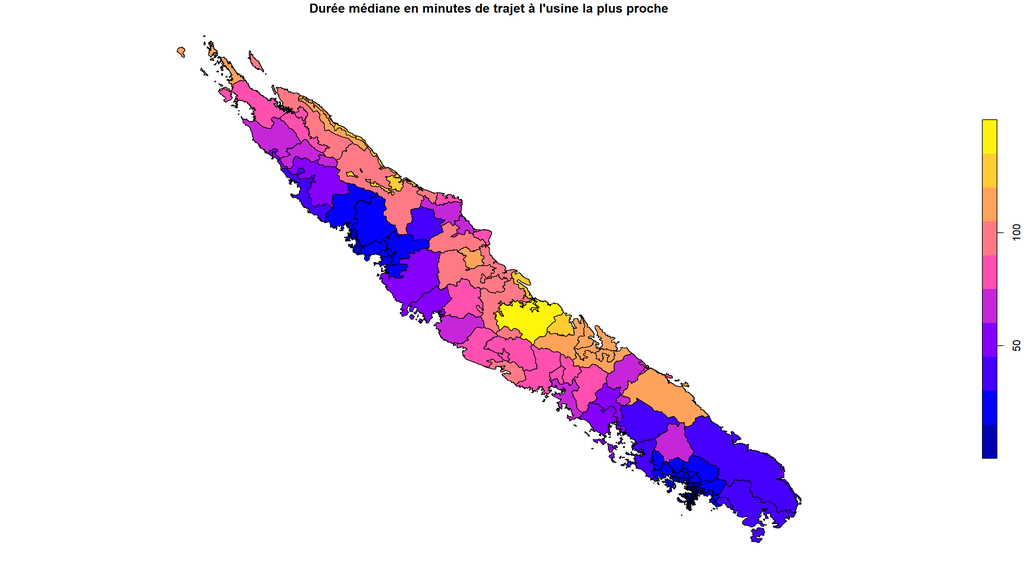

```r
iris %>%
  merge(desserte, by.x = "CODE_IRIS", by.y = 0) %>%
  select("duree_usine") %>%
  plot(
    main = "Durée médiane en minutes de trajet à l'usine la plus proche",
    axes = FALSE,
    key.pos = 4,
    breaks = seq(from = 0, to = 15 * ceiling(max(desserte$duree_usine) / 15), by = 15)
  )
```

On donne la liste des IRIS par durée décroissante d’accès à l’usine, pour les IRIS à plus d’une heure de trajet. Le centre de la grande terre sur les deux côtés et le nord de la côte est sont les plus éloignés des usines.

```r
iris %>%
  merge(desserte, by.x = "CODE_IRIS", by.y = 0) %>%
  arrange(desc(duree_usine)) %>%
  column_to_rownames("CODE_IRIS") %>%
  select(LIB_IRIS, COMM, NOM_COMMUNE, TYPE, COUNT_19, duree_usine) %>%
  filter(duree_usine >= 60)
```

```
##                                              LIB_IRIS COMM NOM_COMMUNE          TYPE COUNT_19 duree_usine
## 0808                        Kua - Néoua - Gwa Ruviano   08    Houailou        minier       48         139
## 0801                                 Houaïlou village   08    Houailou        minier      438         131
## 0704                         Tiendanite à Ouayaguette   07   Hienghène        témoin      210         129
## 0803                                            Waraï   08    Houailou        minier      322         127
## 2402                   Tchamboëne - Diahoué - Colnett   24      Pouébo          <NA>      234         125
## 0701                                Hienghène village   07   Hienghène        témoin      445         121
## 3301                   Kouaoua village - Amon Kasiori   33     Kouaoua          <NA>      213         121
## 0404                                         Mé Kwaré   04      Canala          <NA>       55         120
## 0805                            Nédivin - Bas Nindien   08    Houailou        minier      317         118
## 0401                                   Canala village   04      Canala          <NA>      511         114
## 0403                    Gélima - Kuiné - Mia - Nakéty   04      Canala          <NA>      496         114
## 3302                        Méa Mébara - Ouérou Pimet   33     Kouaoua          <NA>      192         114
## 2906                                          Borendy   29        Thio          <NA>       76         113
## 2405                   Massif du Panié - Mont Colnett   24      Pouébo          <NA>       NA         112
```

[output cut: 38 more lines]

On fait la même chose pour la durée d’accès à un centre minier. On voit que **les communes les plus éloignées sont celles de la côte est de la province Nord** comme Hienghène, Touho, Pouébo ou Poindimié.

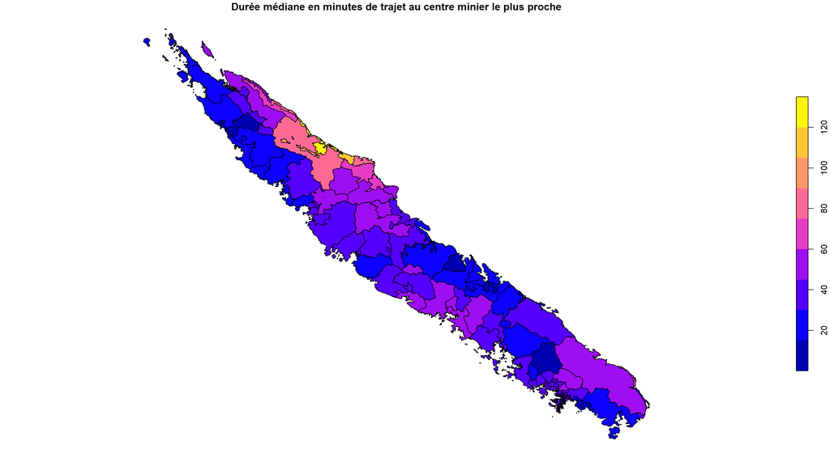

```r
iris %>%
  merge(desserte, by.x = "CODE_IRIS", by.y = 0) %>%
  select("duree_centre") %>%
  plot(
    main = "Durée médiane en minutes de trajet au centre minier le plus proche",
    axes = FALSE,
    key.pos = 4,
    breaks = seq(from = 0, to = 15 * ceiling(max(desserte$duree_centre) / 15), by = 15)
  )
```

```r
iris %>%
  merge(desserte, by.x = "CODE_IRIS", by.y = 0) %>%
  arrange(desc(duree_centre)) %>%
  column_to_rownames("CODE_IRIS") %>%
  select(LIB_IRIS, COMM, NOM_COMMUNE, TYPE, COUNT_19, duree_centre) %>%
  filter(duree_centre >= 60)
```

```
##                                      LIB_IRIS COMM NOM_COMMUNE          TYPE COUNT_19 duree_centre
## 0701                        Hienghène village   07   Hienghène        témoin      445          121
## 3003   Tiouandé - Ouanache - Congouma - Paola   30       Touho          <NA>      199          106
## 0704                 Tiendanite à Ouayaguette   07   Hienghène        témoin      210           98
## 3001                            Touho village   30       Touho          <NA>      339           89
## 0705      Oué - Hawa - Ouen - Kout - Pwa Jilu   07   Hienghène        témoin       24           85
## 2402           Tchamboëne - Diahoué - Colnett   24      Pouébo          <NA>      234           79
## 3004        Koe - Kokingone - Tiwaka - Pombéi   30       Touho          <NA>      186           75
## 2202                              Tiéti - Tyé   22   Poindimié          <NA>      581           68
## 2405           Massif du Panié - Mont Colnett   24      Pouébo          <NA>       NA           66
## 3202                                     Unia   32        Yaté        minier      177           64
## 1108                                   Bopope   11        Koné métallurgique       61           60
## 2401 Pouébo village - St Ferdinand - St Louis   24      Pouébo          <NA>      361           60
```

Enfin, on dessine la carte des durées de trajet vers les centres miniers **ou** les usines métallurgiques. On remarque que le maillage des centre miniers est suffisament dense pour masquer celui des usines : la carte est sensiblement la même que la précédente.

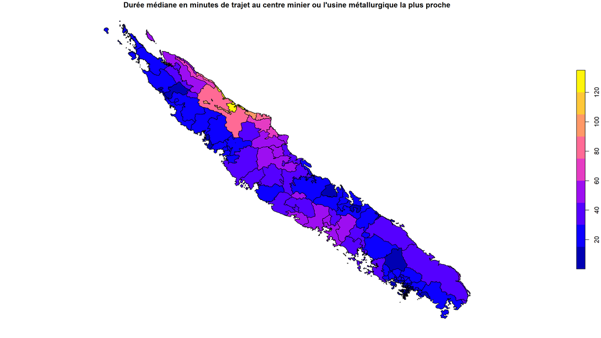

```r
iris %>%
  merge(desserte, by.x = "CODE_IRIS", by.y = 0) %>%
  select("duree_min") %>%
  plot(
    main = "Durée médiane en minutes de trajet au centre minier ou l'usine métallurgique la plus proche",
    axes = FALSE,
    key.pos = 4,
    breaks = seq(from = 0, to = 15 * ceiling(max(desserte$duree_min) / 15), by = 15)
  )
```

### Regressions sur le NEM

On souhaite évaluer l’influence de la distance à la mine et la comparer aux variables `PROV`, `CS8`, `AGER`, `DIPL` sur le NEM100. Les co-facteurs d’intérêt sont tous mis sous forme catégorielle. L’analyse va porter ici sur la BI 2019 jointe à la BL via l’identifiant de logement `IDLOG`. On note qu’il y a 29871 actifs hors du GN dans la BI 2019.

```r
# on va créer quelques colonnes catégorielles correctement labélisées
bl19_desserte <- bl19_bi19 %>%
  filter(NC_BL %notin% grand_noumea) %>%
  merge(desserte, by.x = "IRISUNC_BL", by.y = 0) %>%
  mutate(
    # diplome regroupés
    DIPLR_ = relevel(factor(DIPLR, labels = diplm_labels), ref = 1),
    # CSP
    CS8_ = relevel(factor(CS8, labels = cs8m_labels[1:6]), ref = 1),
    # age révolu à la 10aine ~ groupe d'age décennal
    AGER_ = factor(I(10 * floor(AGER / 10))),
    # durée en 1/4 heures de trajets
    DUREE_USINE_QUART = paste0("DUR_", factor(I(floor(duree_usine / 15)))),
    DUREE_CENTRE_QUART = paste0("DUR_", factor(I(floor(duree_centre / 15)))),
    DUREE_QUART = paste0("DUR_", factor(I(floor(duree_min / 15)))),
    # découpage en déciles du NEM100
    NEM100_DEC = paste0("NEM_", factor(I(ntile(NEM100, n = 10))))
  )
```

Après jointure, on obtient 23579 individus étudiés. Sur ce modèle on constante ci-dessous :

- l’influence positive substantielle **positive** sur le `NEM100` des facteurs suivants :
  - la province (`PROV_BL`)
  - du diplôme (`DIPLR_`) selon la durée des études
  - du groupe d’âge décennal (`AGER_`) croissant
  - de la CSP (`CS8_`)
- l’influence **négative** du nombre de 1/4 d’heures de trajets à une usine, avec toutefois un anneau indéterminé entre 45 et 60 de trajet (facteur `DUREE_USINE_QUARTDUR_3`).

On remarque aussi que les 1/4 d’heures de trajets ne sont **pas ordonnés**, ce qui témoigne **d’une limite de ce facteur**.

```r
model <- glm(NEM100 ~ PROV_BL + DUREE_USINE_QUART + DIPLR_ + AGER_ + CS8_, data = bl19_desserte)
summary(model)
```

```
##
## Call:
## glm(formula = NEM100 ~ PROV_BL + DUREE_USINE_QUART + DIPLR_ +
##     AGER_ + CS8_, data = bl19_desserte)
##
## Deviance Residuals:
##    Min      1Q  Median      3Q     Max
## -90.88  -11.99    1.55   13.56   63.04
##
## Coefficients:
##                                           Estimate Std. Error t value Pr(>|t|)
## (Intercept)                                 74.110      1.297   57.12  < 2e-16 ***
## PROV_BLSud                                   3.223      0.358    9.01  < 2e-16 ***
## DUREE_USINE_QUARTDUR_1                       4.577      0.816    5.61  2.0e-08 ***
## DUREE_USINE_QUARTDUR_2                      -9.301      0.884  -10.52  < 2e-16 ***
## DUREE_USINE_QUARTDUR_3                       1.054      0.842    1.25   0.2106
## DUREE_USINE_QUARTDUR_4                      -6.855      0.874   -7.84  4.6e-15 ***
## DUREE_USINE_QUARTDUR_5                      -7.223      0.825   -8.75  < 2e-16 ***
## DUREE_USINE_QUARTDUR_6                      -2.784      0.944   -2.95   0.0032 **
## DUREE_USINE_QUARTDUR_7                     -14.797      0.844  -17.53  < 2e-16 ***
## DUREE_USINE_QUARTDUR_8                     -11.678      0.879  -13.29  < 2e-16 ***
## DUREE_USINE_QUARTDUR_9                     -24.724      2.847   -8.68  < 2e-16 ***
## DIPLR_CEP                                    0.228      0.854    0.27   0.7896
## DIPLR_BEPC                                   5.540      0.562    9.85  < 2e-16 ***
## DIPLR_CAP/BEP                                5.018      0.367   13.66  < 2e-16 ***
## DIPLR_Bac général                           11.777      0.531   22.17  < 2e-16 ***
## DIPLR_Bac tech./pro.                         8.909      0.499   17.86  < 2e-16 ***
## DIPLR_Bac+2/+3                              15.521      0.571   27.19  < 2e-16 ***
## DIPLR_Bac+5/+8                              16.733      0.563   29.73  < 2e-16 ***
## AGER_20                                     -1.625      1.007   -1.61   0.1066
## AGER_30                                      1.808      1.000    1.81   0.0707 .
## AGER_40                                      4.821      1.002    4.81  1.5e-06 ***
## AGER_50                                      7.290      1.016    7.17  7.6e-13 ***
## AGER_60                                     10.434      1.170    8.92  < 2e-16 ***
## AGER_70                                     17.226      2.193    7.85  4.2e-15 ***
## CS8_Artisans, commerçants et chefs d'ent.   13.216      0.633   20.89  < 2e-16 ***
## CS8_Cadres et professions int. sup.         12.292      0.772   15.91  < 2e-16 ***
## CS8_Professions intermédiaires              10.525      0.580   18.16  < 2e-16 ***
## CS8_Employés                                 6.654      0.529   12.57  < 2e-16 ***
## CS8_Ouvriers                                 4.912      0.502    9.79  < 2e-16 ***
## ---
## Signif. codes:  0 '***' 0.001 '**' 0.01 '*' 0.05 '.' 0.1 ' ' 1
##
## (Dispersion parameter for gaussian family taken to be 389)
##
##     Null deviance: 12422611  on 23578  degrees of freedom
## Residual deviance:  9172706  on 23550  degrees of freedom
## AIC: 207591
##
## Number of Fisher Scoring iterations: 2
```

Avec la représentation par analyse factorielle des correspondances sur les déciles du NEM base 100 on remarque :

- que l’axe des x est **parfaitement ordonné** selon les déciles du NEM100,
- l’ordre des durées de trajet à l’usine est bien moins représenté,
- que le premier facteur catpure 92.3% de la variance.

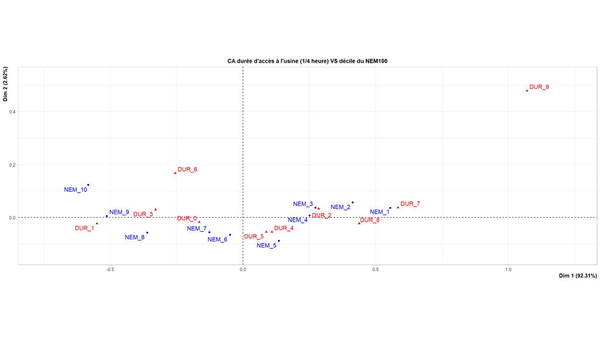

```r
df <- bl19_desserte %>%
  group_by(NEM100_DEC, DUREE_USINE_QUART, .add = TRUE) %>%
  summarise(
    nb = n()
  ) %>%
  pivot_wider(names_from = DUREE_USINE_QUART, values_from = nb, values_fill = 0) %>%
  column_to_rownames("NEM100_DEC")

ca_bl19_desserte <- CA(df, graph = FALSE)
plot(ca_bl19_desserte, title = "CA durée d'accès à l'usine (1/4 heure) VS décile du NEM100")
```

```r
summary(ca_bl19_desserte)
```

```
##
## Call:
## CA(X = df, graph = FALSE)
##
## The chi square of independence between the two variables is equal to 3542 (p-value =  0 ).
##
## Eigenvalues
##                        Dim.1   Dim.2   Dim.3   Dim.4   Dim.5   Dim.6   Dim.7   Dim.8   Dim.9
## Variance               0.139   0.004   0.003   0.002   0.001   0.001   0.000   0.000   0.000
## % of var.             92.308   2.623   2.169   1.508   0.700   0.360   0.223   0.105   0.004
## Cumulative % of var.  92.308  94.931  97.100  98.608  99.308  99.668  99.891  99.996 100.000
##
## Rows
##          Iner*1000    Dim.1    ctr   cos2    Dim.2    ctr   cos2    Dim.3    ctr   cos2
## NEM_1  |    32.415 |  0.555 22.229  0.951 |  0.036  3.278  0.004 |  0.111 37.733  0.038 |
## NEM_10 |    35.842 | -0.583 24.471  0.947 |  0.123 38.256  0.042 | -0.017  0.890  0.001 |
## NEM_2  |    17.958 |  0.414 12.380  0.956 |  0.057  8.169  0.018 |  0.012  0.419  0.001 |
## NEM_3  |     9.666 |  0.274  5.400  0.775 |  0.037  3.496  0.014 | -0.116 41.286  0.139 |
## NEM_4  |     7.068 |  0.251  4.544  0.891 |  0.008  0.155  0.001 | -0.031  2.919  0.013 |
## NEM_5  |     3.178 |  0.136  1.333  0.582 | -0.088 19.616  0.243 | -0.029  2.539  0.026 |
## NEM_6  |     1.014 | -0.048  0.168  0.229 | -0.065 10.852  0.422 | -0.026  2.128  0.068 |
## NEM_7  |     2.294 | -0.127  1.155  0.698 | -0.056  7.817  0.134 |  0.035  3.846  0.055 |
## NEM_8  |    13.579 | -0.360  9.351  0.955 | -0.057  8.282  0.024 |  0.010  0.317  0.001 |
## NEM_9  |    27.206 | -0.513 18.970  0.967 |  0.006  0.079  0.000 |  0.051  7.922  0.009 |
##
## Columns
##          Iner*1000    Dim.1    ctr   cos2    Dim.2    ctr   cos2    Dim.3    ctr   cos2
## DUR_0  |     1.305 | -0.164  0.568  0.603 | -0.018  0.231  0.007 |  0.013  0.147  0.004 |
## DUR_1  |    53.723 | -0.550 38.242  0.987 | -0.022  2.223  0.002 |  0.035  6.588  0.004 |
## DUR_2  |     9.209 |  0.285  4.953  0.746 |  0.033  2.384  0.010 | -0.132 45.188  0.160 |
## DUR_3  |    13.892 | -0.329  9.554  0.954 |  0.030  2.807  0.008 | -0.023  1.942  0.005 |
## DUR_4  |     3.176 |  0.110  0.982  0.428 | -0.054  8.510  0.106 | -0.074 18.880  0.194 |
## DUR_5  |     2.502 |  0.088  1.148  0.636 | -0.054 15.606  0.246 |  0.028  4.889  0.064 |
## DUR_6  |     6.906 | -0.255  3.317  0.666 |  0.168 50.326  0.287 | -0.006  0.067  0.000 |
## DUR_7  |    39.900 |  0.584 28.207  0.980 |  0.038  4.093  0.004 |  0.061 13.034  0.011 |
## DUR_8  |    15.911 |  0.438 11.209  0.977 | -0.022  1.015  0.003 |  0.034  2.898  0.006 |
## DUR_9  |     3.699 |  1.070  1.821  0.683 |  0.478 12.805  0.136 |  0.307  6.367  0.056 |
```

On va faire similairement avec la durée au centre minier et celles globables (usine ou centre) avec les mêmes co-facteurs. Pour les centres miniers, la corrélation est moins nette sur la durée de trajet.

```r
model <- glm(NEM100 ~ PROV_BL + DUREE_CENTRE_QUART + DIPLR_ + AGER_ + CS8_, data = bl19_desserte)
summary(model)
```

```
##
## Call:
## glm(formula = NEM100 ~ PROV_BL + DUREE_CENTRE_QUART + DIPLR_ +
##     AGER_ + CS8_, data = bl19_desserte)
##
## Deviance Residuals:
##    Min      1Q  Median      3Q     Max
## -85.68  -12.44    1.41   14.09   61.19
##
## Coefficients:
##                                           Estimate Std. Error t value Pr(>|t|)
## (Intercept)                                 67.755      1.161   58.34  < 2e-16 ***
## PROV_BLSud                                  -0.106      0.311   -0.34  0.73207
## DUREE_CENTRE_QUARTDUR_1                     -4.353      0.484   -8.99  < 2e-16 ***
## DUREE_CENTRE_QUARTDUR_2                      2.554      0.456    5.60  2.1e-08 ***
## DUREE_CENTRE_QUARTDUR_3                      3.362      0.475    7.08  1.4e-12 ***
## DUREE_CENTRE_QUARTDUR_4                     -8.582      0.746  -11.51  < 2e-16 ***
## DUREE_CENTRE_QUARTDUR_5                     -2.754      0.839   -3.28  0.00103 **
## DUREE_CENTRE_QUARTDUR_6                    -18.750      1.593  -11.77  < 2e-16 ***
## DUREE_CENTRE_QUARTDUR_7                     -2.168      1.814   -1.19  0.23212
## DUREE_CENTRE_QUARTDUR_8                     -3.596      1.049   -3.43  0.00061 ***
## DIPLR_CEP                                    0.794      0.879    0.90  0.36659
## DIPLR_BEPC                                   6.531      0.578   11.30  < 2e-16 ***
## DIPLR_CAP/BEP                                5.772      0.378   15.28  < 2e-16 ***
## DIPLR_Bac général                           12.972      0.545   23.78  < 2e-16 ***
## DIPLR_Bac tech./pro.                        10.590      0.511   20.73  < 2e-16 ***
## DIPLR_Bac+2/+3                              17.948      0.583   30.78  < 2e-16 ***
## DIPLR_Bac+5/+8                              18.862      0.576   32.76  < 2e-16 ***
## AGER_20                                     -1.520      1.036   -1.47  0.14239
## AGER_30                                      1.858      1.029    1.80  0.07112 .
## AGER_40                                      4.898      1.031    4.75  2.1e-06 ***
## AGER_50                                      7.278      1.046    6.96  3.6e-12 ***
## AGER_60                                     10.823      1.204    8.99  < 2e-16 ***
## AGER_70                                     18.369      2.257    8.14  4.2e-16 ***
## CS8_Artisans, commerçants et chefs d'ent.   14.591      0.650   22.46  < 2e-16 ***
## CS8_Cadres et professions int. sup.         14.875      0.790   18.82  < 2e-16 ***
## CS8_Professions intermédiaires              11.987      0.595   20.16  < 2e-16 ***
## CS8_Employés                                 7.723      0.543   14.22  < 2e-16 ***
## CS8_Ouvriers                                 6.034      0.515   11.73  < 2e-16 ***
## ---
## Signif. codes:  0 '***' 0.001 '**' 0.01 '*' 0.05 '.' 0.1 ' ' 1
##
## (Dispersion parameter for gaussian family taken to be 413)
##
##     Null deviance: 12422611  on 23578  degrees of freedom
## Residual deviance:  9718702  on 23551  degrees of freedom
## AIC: 208952
##
## Number of Fisher Scoring iterations: 2
```

Ce qui impact la durée minimum centre ou usine.

```r
model <- glm(NEM100 ~ PROV_BL + DUREE_QUART + DIPLR_ + AGER_ + CS8_, data = bl19_desserte)
summary(model)
```

```
##
## Call:
## glm(formula = NEM100 ~ PROV_BL + DUREE_QUART + DIPLR_ + AGER_ +
##     CS8_, data = bl19_desserte)
##
## Deviance Residuals:
##    Min      1Q  Median      3Q     Max
## -88.79  -12.57    1.47   14.21   62.81
##
## Coefficients:
##                                           Estimate Std. Error t value Pr(>|t|)
## (Intercept)                                 67.127      1.153   58.20  < 2e-16 ***
## PROV_BLSud                                   1.663      0.350    4.75  2.0e-06 ***
## DUREE_QUARTDUR_1                             0.500      0.418    1.20  0.23156
## DUREE_QUARTDUR_2                            -2.722      0.459   -5.93  3.0e-09 ***
## DUREE_QUARTDUR_3                             0.973      0.505    1.93  0.05383 .
## DUREE_QUARTDUR_4                            -8.937      0.691  -12.93  < 2e-16 ***
## DUREE_QUARTDUR_5                            -1.370      0.953   -1.44  0.15046
## DUREE_QUARTDUR_6                           -11.892      1.227   -9.69  < 2e-16 ***
## DUREE_QUARTDUR_8                            -4.023      1.043   -3.86  0.00011 ***
## DIPLR_CEP                                    0.727      0.886    0.82  0.41169
## DIPLR_BEPC                                   6.523      0.583   11.20  < 2e-16 ***
## DIPLR_CAP/BEP                                5.902      0.381   15.51  < 2e-16 ***
## DIPLR_Bac général                           13.358      0.549   24.31  < 2e-16 ***
## DIPLR_Bac tech./pro.                        10.908      0.515   21.20  < 2e-16 ***
## DIPLR_Bac+2/+3                              18.637      0.587   31.77  < 2e-16 ***
## DIPLR_Bac+5/+8                              19.622      0.579   33.89  < 2e-16 ***
## AGER_20                                     -1.367      1.045   -1.31  0.19055
## AGER_30                                      2.078      1.037    2.00  0.04522 *
## AGER_40                                      5.211      1.039    5.01  5.4e-07 ***
## AGER_50                                      7.635      1.054    7.24  4.5e-13 ***
## AGER_60                                     11.069      1.214    9.12  < 2e-16 ***
## AGER_70                                     18.041      2.275    7.93  2.3e-15 ***
## CS8_Artisans, commerçants et chefs d'ent.   15.482      0.653   23.71  < 2e-16 ***
## CS8_Cadres et professions int. sup.         15.866      0.794   19.97  < 2e-16 ***
## CS8_Professions intermédiaires              12.541      0.598   20.97  < 2e-16 ***
## CS8_Employés                                 8.514      0.545   15.61  < 2e-16 ***
## CS8_Ouvriers                                 6.612      0.518   12.78  < 2e-16 ***
## ---
## Signif. codes:  0 '***' 0.001 '**' 0.01 '*' 0.05 '.' 0.1 ' ' 1
##
## (Dispersion parameter for gaussian family taken to be 419)
##
##     Null deviance: 12422611  on 23578  degrees of freedom
## Residual deviance:  9873276  on 23552  degrees of freedom
## AIC: 209322
##
## Number of Fisher Scoring iterations: 2
```